# AIFFD Chapter 4 - Recruitment

Derek H. Ogle

This document contains R versions of the boxed examples from **Chapter 4** of the *Analysis and Interpretation of Freshwater Fisheries Data* book. Some sections build on descriptions from previous sections, so each section may not stand completely on its own. More thorough discussions of linear models; type-I, II, and III sums-of-squares, and least-squares means are found in the [preliminaries vignette](https://fishr.wordpress.com/books/aiffd/).

The following additional packages are required to complete all of the examples (with the required functions noted as a comment and also noted in the specific examples below).

```r
> library(FSA)          # fitPlot, Subset
> library(NCStats)      # addSigLetters
> library(car)          # Anova, durbinWatsonTest, vif
> library(Hmisc)        # rcorr
> library(Kendall)      # kendall
> library(lsmeans)      # lsmeans
> library(multcomp)     # glht, mcp, cld
> library(nlstools)     # overview, nlsBoot
> library(plotrix)      # thigmophobe.labels, rescale
```

In addition, external tab-delimited text files are used to hold the data required for each example. These data are loaded into R in each example with `read.table()`. Before using `read.table()` the working directory of R must be set to where these files are located on **your** computer. The working directory for all data files on **my** computer is set below.

```r
> setwd("c:/aaaWork/web/fishR/BookVignettes/AIFFD/")
```

I also prefer to not show significance stars for hypothesis test output and set contrasts in such a manner as to force R output to match SAS output for linear model summaries. These options are set below.

```r
> options(show.signif.stars=FALSE,contrasts=c("contr.sum","contr.poly"))
```

Finally, I set the random number seed so that the boostrapping results can be repeated.

```r
> set.seed(983452)
```

## 4.1 Log-Linear Model to Test for Year-Class Abundance Differences

Below we conduct a test for year-class abundance differences among the 1990 to 1997 year-classes (`yearcl`) based on catch rates of age-0, age-1, and age-2 crappies (*Pomoxis* spp.) (`age` in years) from Weiss Lake (Table 4.1 in text). Trap-net catch rates (`catch`) were transformed to natural log values to homogenize variances as recommended by Kimura (1988) for log-linear analysis. The data in Table 4.1 were rearranged to conduct the analysis. Year of collection (`yearcol`) was included in the data file, and the following R code was used to conduct the analysis.

### 4.1.1 Preparing Data

The [`box4_1.txt`](https://raw.githubusercontent.com/droglenc/aiffd2007/master/data/Box4_1.txt) is read, the structure of the data frame is observed, and a new variable, `lcatch`, that is the natural log of the catch variable is created.

```r
> d1 <- read.table("data/box4_1.txt",header=TRUE)
> str(d1)
```

```
'data.frame':   24 obs. of  4 variables:
 $ yearcol: int  1990 1991 1992 1991 1992 1993 1992 1993 1994 1993 ...
 $ yearcl : int  1990 1990 1990 1991 1991 1991 1992 1992 1992 1993 ...
 $ age    : int  0 1 2 0 1 2 0 1 2 0 ...
 $ catch  : num  8.03 5.32 2.43 0.47 0.39 0.39 0.61 0.97 0.61 1.38 ...
```

```r
> d1$lcatch <- log(d1$catch)
```

In addition, R must be told explicitly that `age` and `yearcl` are group factor rather than numeric variables.

```r
> d1$age <- factor(d1$age)
> d1$yearcl <- factor(d1$yearcl)
```

### 4.1.2 Two-Way ANOVA Model

The authors of the box fit a two-way ANOVA with**OUT** an interaction term. While a two-way ANOVA is generally fit with an interaction term, not using an interaction term is appropriate here because an interaction cannot be estimated as there are not multiple observations for each combination of the two factors. This fact is best illustrated with a two-way frequency table constructed from the two group factor variables with `xtabs()`.

```r
> xtabs(~age+yearcl,data=d1)
```

```
   yearcl
age 1990 1991 1992 1993 1994 1995 1996 1997
  0    1    1    1    1    1    1    1    1
  1    1    1    1    1    1    1    1    1
  2    1    1    1    1    1    1    1    1
```

The two-way ANOVA model without the interaction term is fit with `lm()`. The ANOVA table using type-III SS is then extracted from the `lm()` object with `Anova()` from the `car` package. From this, there is evidence for a significant difference in means among ages and among year-classes.

```r
> lm1 <- lm(lcatch~age+yearcl,data=d1)
> Anova(lm1,type="III")
```

```
             Sum Sq     Df F value    Pr(>F)
(Intercept)  2.7457  1.000 12.4839  0.003309
age          4.0952  2.000  9.3097  0.002683
yearcl      19.0150  7.000 12.3508 4.994e-05
Residuals    3.0792 14.000
Total       24.0000 28.935
```

### 4.1.3 Least-Squares Means for Year-Class

Least-squares means are computed with `lsmeans()` from the `lsmeans` package using a right-hand-sided formula as the second argument to isolate the least-square means for each factor variable. From this, it appears that CPE generally decreases (not surprisingly) with age and that 1990 and 1996 are relatively strong year-classes and 1991 is a relatively poor year-class.

```r
> lsmeans(lm1,~age)
```

```
 age     lsmean        SE df   lower.CL  upper.CL
 0    0.6973961 0.1658088 14  0.3417717 1.0530205
 1    0.5576609 0.1658088 14  0.2020365 0.9132853
 2   -0.2403432 0.1658088 14 -0.5959676 0.1152812

Results are averaged over the levels of: yearcl
Confidence level used: 0.95
```

```r
> lsmeans(lm1,~yearcl)
```

```
 yearcl     lsmean        SE df    lower.CL   upper.CL
 1990    1.5475164 0.2707646 14  0.96678413  2.1282486
 1991   -0.8794132 0.2707646 14 -1.46014545 -0.2986810
 1992   -0.3396840 0.2707646 14 -0.92041618  0.2410483
 1993    0.6259558 0.2707646 14  0.04522358  1.2066880
 1994    0.6280314 0.2707646 14  0.04729921  1.2087637
 1995   -0.2701080 0.2707646 14 -0.85084020  0.3106243
 1996    1.7311522 0.2707646 14  1.15041997  2.3118844
 1997   -0.3375473 0.2707646 14 -0.91827955  0.2431849

Results are averaged over the levels of: age
Confidence level used: 0.95
```

### 4.1.4 Multiple Comparisons

The authors of the box use Fisher’s LSD multiple comparison procedure. In general, this procedure does not guard well against an inflated experimentwise error rate. In general, Tukey’s HSD procedure performs better in this regard and will be illustrated below.

Tukey’s multiple comparison procedure, implemented through `glht()` from the `multcomp` package, can be used to identify where the differences in means occur. The `glht()` function requires the `lm()` object as the first argument. The second argument is also required and uses `mcp()` to declare a “multiple comparison procedure.” In this instance the argument to `mcp()` is the factor variable in the `lm()` object for which you are testing for differences set equal to the `"Tukey"` string. The result from `glht()` is saved to an object that can be submitted to `summary()` to extract p-values for each difference in pairs of means, to `confint()` to extract confidence intervals for each difference in pairs of means, and to `cld()` to identify significance letters that depict significant differences among means.

```r
> mc1a <- glht(lm1,mcp(age="Tukey"))
> summary(mc1a)
```

```
           Estimate Std. Error t value Pr(>|t|)
1 - 0 == 0  -0.1397     0.2345  -0.596  0.82457
2 - 0 == 0  -0.9377     0.2345  -3.999  0.00348
2 - 1 == 0  -0.7980     0.2345  -3.403  0.01113
```

```r
> mc1yc <- glht(lm1,mcp(yearcl="Tukey"))
> summary(mc1yc)
```

```
                  Estimate Std. Error t value Pr(>|t|)
1991 - 1990 == 0 -2.426930   0.382919  -6.338  < 0.001
1992 - 1990 == 0 -1.887200   0.382919  -4.928  0.00417
1993 - 1990 == 0 -0.921561   0.382919  -2.407  0.30867
1994 - 1990 == 0 -0.919485   0.382919  -2.401  0.31101
1995 - 1990 == 0 -1.817624   0.382919  -4.747  0.00563
1996 - 1990 == 0  0.183636   0.382919   0.480  0.99959
1997 - 1990 == 0 -1.885064   0.382919  -4.923  0.00408
1992 - 1991 == 0  0.539729   0.382919   1.410  0.83898
1993 - 1991 == 0  1.505369   0.382919   3.931  0.02440
1994 - 1991 == 0  1.507445   0.382919   3.937  0.02412
1995 - 1991 == 0  0.609305   0.382919   1.591  0.74834
1996 - 1991 == 0  2.610565   0.382919   6.818  < 0.001
1997 - 1991 == 0  0.541866   0.382919   1.415  0.83650
1993 - 1992 == 0  0.965640   0.382919   2.522  0.26162
1994 - 1992 == 0  0.967715   0.382919   2.527  0.25991
1995 - 1992 == 0  0.069576   0.382919   0.182  1.00000
1996 - 1992 == 0  2.070836   0.382919   5.408  0.00171
1997 - 1992 == 0  0.002137   0.382919   0.006  1.00000
1994 - 1993 == 0  0.002076   0.382919   0.005  1.00000
1995 - 1993 == 0 -0.896064   0.382919  -2.340  0.33844
1996 - 1993 == 0  1.105196   0.382919   2.886  0.14944
1997 - 1993 == 0 -0.963503   0.382919  -2.516  0.26428
1995 - 1994 == 0 -0.898139   0.382919  -2.346  0.33553
1996 - 1994 == 0  1.103121   0.382919   2.881  0.15063
1997 - 1994 == 0 -0.965579   0.382919  -2.522  0.26189
1996 - 1995 == 0  2.001260   0.382919   5.226  0.00229
1997 - 1995 == 0 -0.067439   0.382919  -0.176  1.00000
1997 - 1996 == 0 -2.068700   0.382919  -5.402  0.00180
```

```r
> cld(mc1yc)
```

```
1990 1991 1992 1993 1994 1995 1996 1997
 "c"  "a" "ab" "bc" "bc" "ab"  "c" "ab"
```

An plot of the group means, with appropriate confidence intervals is constructed with `fitPlot()` from the `FSA` package. The significance letters can be added to the means plot with `addSigLetters()` from the `NCStats` package. See `?addSigLetters` for a description of the arguments.

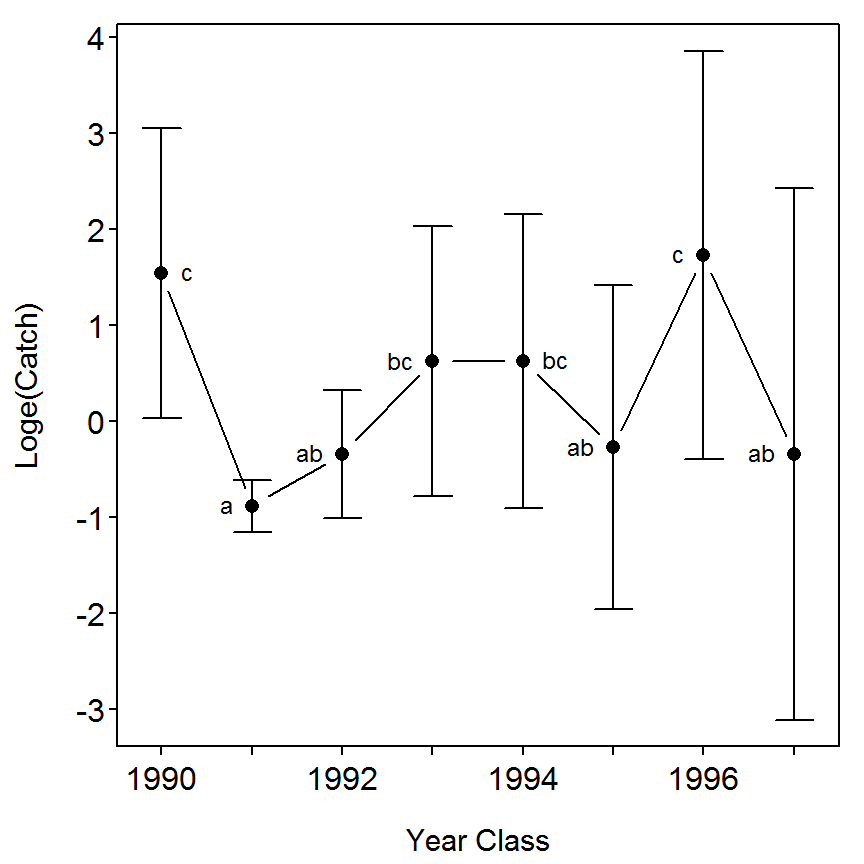

```r
> fitPlot(lm1,which="yearcl",xlab="Year Class",ylab="Loge(Catch)",main="")
> addSigLetters(lm1,which="yearcl",lets=c("c","a","ab","bc","bc","ab","c","ab"),
                pos=c(4,2,2,2,4,2,2,2),cex=0.75)
```

## 4.2 Evaluation of Time Series Trends in Recruit Abundance

The following code presents a plot and computes the Pearson correlation coefficient between age-0 C/f (`age0cpe`) of white bass (*Morone chrysops*) and year and the Kendall tau-b non-parametric correlation coefficient for ranks between these two variables (data published in Madenjian et al. (2000)). In addition, the simple linear regression between C/f and year was computed along with the Durbin-Watson statistic to determine temporal autocorrelation. Finally, the residuals from the regression were plotted against year.

### 4.2.1 Preparing Data

```r
> d2 <- read.table("data/box4_2.txt",header=TRUE)
> str(d2)
```

```
'data.frame':   29 obs. of  2 variables:
 $ year   : int  1969 1970 1971 1972 1973 1974 1975 1976 1977 1978 ...
 $ age0cpe: num  206.08 202.51 75.17 24.38 4.29 ...
```

```r
> d2a <- Subset(d2,year>=1972)
> str(d2a)
```

```
'data.frame':   26 obs. of  2 variables:
 $ year   : int  1972 1973 1974 1975 1976 1977 1978 1979 1980 1981 ...
 $ age0cpe: num  24.38 4.29 10.06 18.16 23.44 ...
```

### 4.2.2 Summary Plot and Statistics

The authors of the box initially plot age-0 CPE against year. This plot is constructed in R with the first use of `plot()` below. I prefer to connect the points to more easily see the year-to-year pattern. This modification is accomplished with the second use of `plot()` below (note the use of `type="b"` where `"b"` is for “both”" points and lines.)

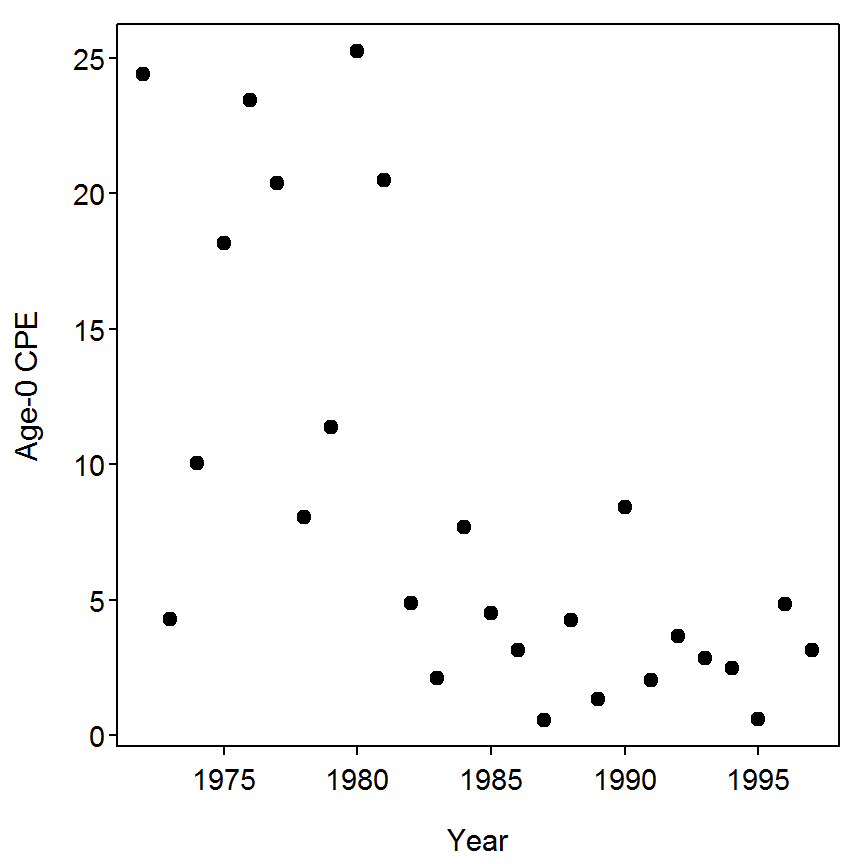

```r
> plot(age0cpe~year,data=d2a,ylab="Age-0 CPE",xlab="Year",main="",pch=19)
```

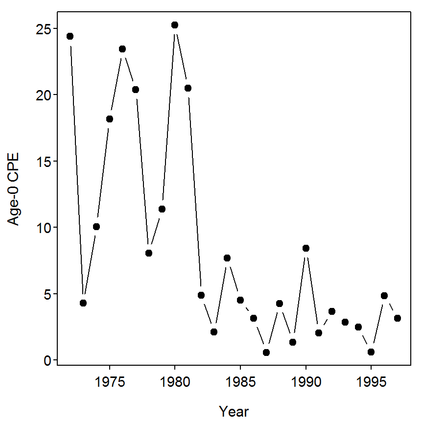

```r
> plot(age0cpe~year,data=d2a,type="b",ylab="Age-0 CPE",xlab="Year",main="",pch=19)
```

The summary statistics presented in the box are efficiently computed with `Summarize()` from the `FSA` package.

```r
> Summarize(d2a$age0cpe,digits=4)
```

```
       n   nvalid     mean       sd      min       Q1   median       Q3
 26.0000  26.0000   8.5535   8.0782   0.5700   2.9150   4.6850  11.0400
     max percZero
 25.2400   0.0000
```

```r
> Summarize(d2a$year,digits=4)
```

```
        n    nvalid      mean        sd       min        Q1    median        Q3
  26.0000   26.0000 1984.5000    7.6485 1972.0000 1978.0000 1984.0000 1991.0000
      max  percZero
1997.0000    0.0000
```

### 4.2.3 Pearson Correlation Analysis

The authors of the box examined the correlation coefficient between `age0cpe` and `year`, with p-values corresponding to a test of whether the correlation is equal to zero or not. The `rcorr()` function from the `Hmisc` package is needed to compute both the correlation coefficients AND the corresponding p-values. [*NOTE: The correlation coefficients alone are computed with `cor` in base R.*] The `rcorr()` function requires a **matrix** as the first argument so the two variables in the data frame must first be isolated and then coerced to a matrix with `as.matrix()`.

```r
> rcorr(as.matrix(d2a[,c("age0cpe","year")]))
```

```
        age0cpe  year
age0cpe    1.00 -0.67
year      -0.67  1.00

n= 26


P
        age0cpe year
age0cpe         2e-04
year    2e-04
```

It should be noted that the relationship between `age0cpe` and `year` is clearly non-linear (as observed from the previous plot) indicating that the value of the correlation coefficient is not strictly interpretable (i.e., correlation coefficients assume a linear relationship).

### 4.2.4 Kendall’s Tau Correlation Analysis}

Kendall’s tau-b correlation coefficient is computed by submitting the two variables as the first two arguments to `Kendall()` from the `Kendall` package.

```r
> Kendall(d2a$age0cpe,d2a$year)
```

```
tau = -0.487, 2-sided pvalue =0.00053745
```

### 4.2.5 Analysis of Residuals from Regression}

The simple linear regression described in the box is fit with `lm()`. The ANOVA table is extracted from the `lm()` object with `anova()` and the coefficients or estimated parameters, among other summary information, is extracted with `summary()`. Because of the evident non-linearity, this result is of dubious value. However, if it were to be interpreted, it shows a significant negative relationship between age-0 CPE and year.

```r
> lm1 <- lm(age0cpe~year,data=d2a)
> anova(lm1)
```

```
          Df  Sum Sq Mean Sq F value    Pr(>F)
year       1  736.99  736.99  19.775 0.0001695
Residuals 24  894.44   37.27
Total     25 1631.43
```

```r
> summary(lm1)
```

```
Coefficients:
             Estimate Std. Error t value Pr(>|t|)
(Intercept) 1417.3042   316.7934   4.474 0.000158
year          -0.7099     0.1596  -4.447 0.000170

Residual standard error: 6.105 on 24 degrees of freedom
Multiple R-squared: 0.4517, Adjusted R-squared: 0.4289
F-statistic: 19.78 on 1 and 24 DF,  p-value: 0.0001695
```

```r
> durbinWatsonTest(lm1,max.lag=5)
```

```
 lag Autocorrelation D-W Statistic p-value
   1       0.2162394      1.500086   0.112
   2      -0.3226973      2.383062   0.310
   3      -0.1726707      2.043186   0.794
   4       0.2916256      1.104914   0.042
   5       0.2046703      1.191092   0.162
 Alternative hypothesis: rho[lag] != 0
```

The residuals from the model fit are stored in the `$residuals` object of the `lm()` object. These residuals can be accessed to construct a plot of residuals versus year.

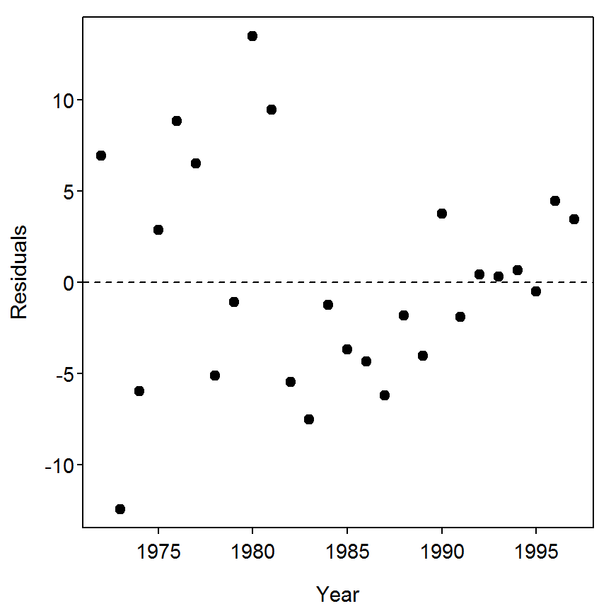

```r
> plot(lm1$residuals~d2a$year,ylab="Residuals",xlab="Year",main="",pch=19)
> abline(h=0,lty=2)                          # adds horizontal reference line at 0
```

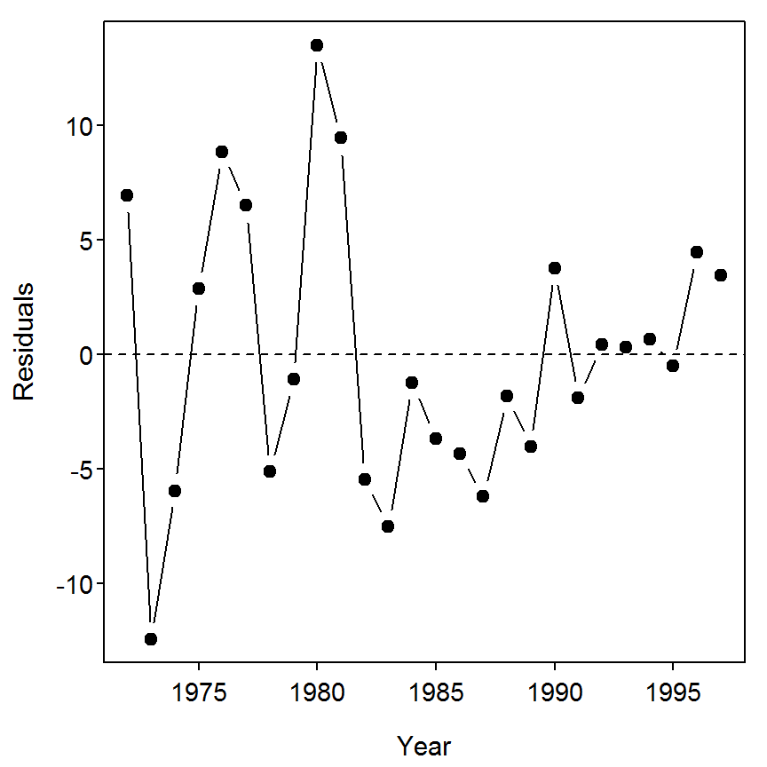

```r
> plot(lm1$residuals~d2a$year,type="b",ylab="Residuals",xlab="Year",main="",pch=19)
> abline(h=0,lty=2)
```

### 4.2.6 An Alternative Residual Analysis}

The results from above indicate that a strong overall trend in the CPE data by year – i.e., high and variable CPE in the early years followed by a much lower and less variable CPE in the later years. The simple linear regression does not represent this trend very well as exhibited by the residual plot (above) and the following fitted-line plot constructed with `fitPlot()` from the `FSA` package.}.

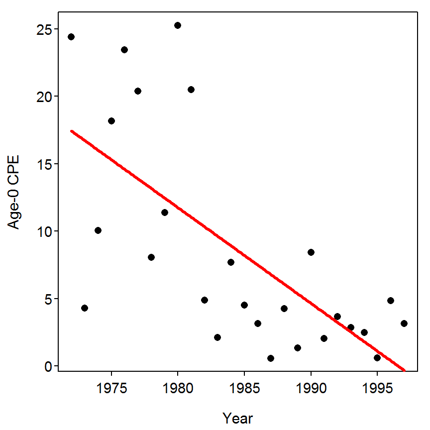

```r
> fitPlot(lm1,ylab="Age-0 CPE",xlab="Year",main="")
```

If the age-0 CPE is transformed to the log scale (new variable called `logage0cpe`) and a new linear model is fit then trends in the residuals with the overall trend removed more appropriately can be examined.

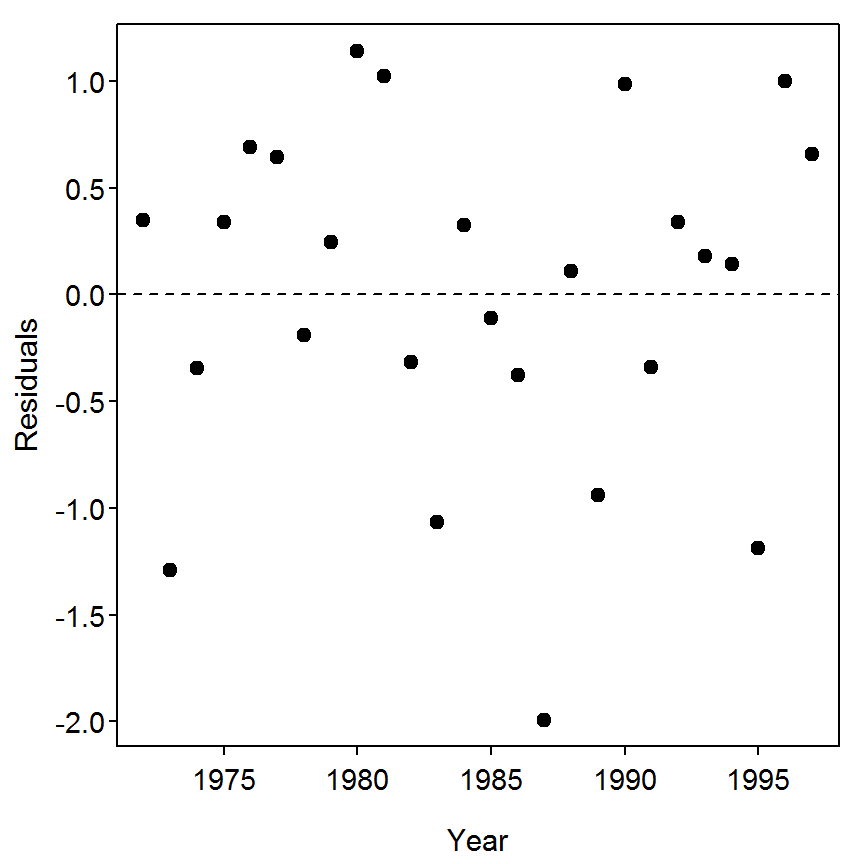

```r
> d2a$logage0cpe <- log(d2a$age0cpe)
> lm2 <- lm(logage0cpe~year,data=d2a)
> plot(lm2$residuals~d2a$year,ylab="Residuals",xlab="Year",main="",pch=19)
> abline(h=0,lty=2)                          # adds horizontal reference line at 0
```

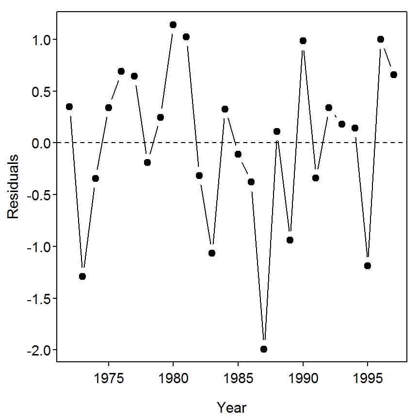

```r
> plot(lm2$residuals~d2a$year,type="b",ylab="Residuals",xlab="Year",main="",pch=19)
> abline(h=0,lty=2)
```

With these changes, there is a significant negative trend in the relationship between log CPE of age-0 fish by year and neither the Durbin-Watson statistic (there is a weak suggestion for a time-lag of four years) or the auto-correlation function test (implemented with `ccf()`) found a significant auto-correlation in the data.

```r
> anova(lm2)
```

```
          Df Sum Sq Mean Sq F value    Pr(>F)
year       1 12.983 12.9833  19.714 0.0001725
Residuals 24 15.806  0.6586
Total     25 28.789
```

```r
> summary(lm2)
```

```
Coefficients:
             Estimate Std. Error t value Pr(>|t|)
(Intercept) 188.64581   42.11253    4.48 0.000156
year         -0.09422    0.02122   -4.44 0.000173

Residual standard error: 0.8115 on 24 degrees of freedom
Multiple R-squared: 0.451,  Adjusted R-squared: 0.4281
F-statistic: 19.71 on 1 and 24 DF,  p-value: 0.0001725
```

```r
> durbinWatsonTest(lm2,max.lag=5)
```

```
 lag Autocorrelation D-W Statistic p-value
   1    -0.003428693      1.971829   0.770
   2    -0.008081435      1.812510   0.554
   3    -0.220896027      2.141396   0.560
   4     0.291742801      1.107594   0.058
   5    -0.050812342      1.760729   0.956
 Alternative hypothesis: rho[lag] != 0
```

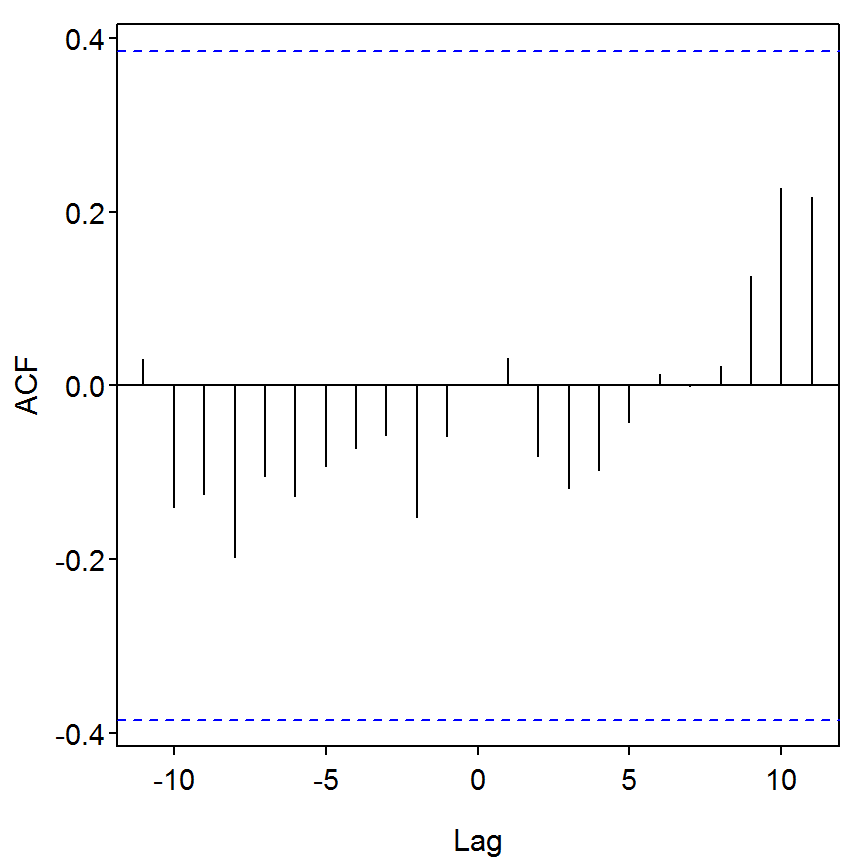

```r
> ccf(lm2$residuals,d2a$year)
```

For completeness, a fitted-“line” plot of the this alternative model to the original data is constructed by predicting log age-0 CPE for each year, back-transforming these values (i.e., using as the power of $e$), and the plotting the back-transformed values against year on top of a plot that already has the original values plotted against year.

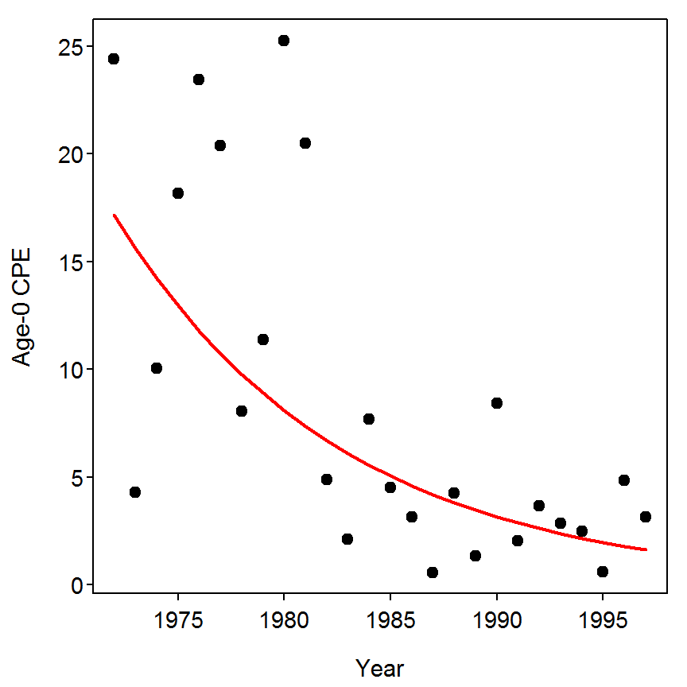

```r
> plot(age0cpe~year,data=d2a,ylab="Age-0 CPE",xlab="Year",pch=19)
> pCPE <- exp(predict(lm2))
> lines(pCPE~d2a$year,lwd=2,col="red")
```

## 4.3 Evaluation of Spatial Differences in Recruit Abundance

Table 4.2 (in text) contains a data set to test for spatial differences in age-0 largemouth bass (*Micropterus salmoides*) catch in Lake Normandy, Tennessee (data from Sammons and Bettoli (2000)). In this example, four distinct areas of the reservoir (Lower Basin [LB], Riley Creek [RC], Upper Basin [UB], and Carroll Creek [CC]) were chosen to examine spatial variation in abundance of fish along 100-m shoreline electrofishing transects. A handheld DC electrofishing unit was used at night. Six fixed sites, or replicate transects, were chosen within each area and sampled three times at 2-week intervals starting the second week of August 1992 and ending the second week of September 1992. Thus, 24 transects were conducted over three time intervals for a total of 72 transects, or observations.

Because replicate samples were collected at fixed locations over the three time periods within each of the same areas, a split-plot repeated-measured ANOVA was used to test for differences in number of fish among areas (Maceina et al. 1994). In addition, this analysis also tested for differences in catch over time and examined the time x area interaction. The code and analysis were divided into main-plot A, which included the class variables `area`, replicates (`rep`), and the `area x rep` interaction, and subplot B, which contained the `time` and the `time x area` interaction effects. The mean square error (MS, or type III sums of squares) of the `area x rep` term was used as the error term in the denominator and the MS error for `area` as the numerator of an F-test to determine if statistical differences in the number caught among the four areas in main-plot A. The MS error generated from the entire ANOVA was used in the denominator of the F-test to determine if statistical differences in `catch` occurred over the three time periods (subplot B), as well as for testing for any interaction between time periods and areas (subplot B).

The following R code provides output to test for differences in catch among areas.

### 4.3.1 Preparing Data

The [`box4_3.txt`](https://raw.githubusercontent.com/droglenc/aiffd2007/master/data/Box4_3.txt) data file is read and the structure of the data frame is observed below. The `rep` and `time` variables are converted to group factor variables for the analysis.

```r
> d3 <- read.table("data/box4_3.txt",header=TRUE)
> str(d3)
```

```
'data.frame':   72 obs. of  6 variables:
 $ year : int  92 92 92 92 92 92 92 92 92 92 ...
 $ month: int  8 8 8 8 8 8 8 8 8 8 ...
 $ area : Factor w/ 4 levels "CC","LB","RC",..: 1 1 1 1 1 1 2 2 2 2 ...
 $ rep  : int  1 2 3 4 5 6 1 2 3 4 ...
 $ time : int  1 1 1 1 1 1 1 1 1 1 ...
 $ count: int  0 3 0 0 2 1 4 2 11 3 ...
```

```r
> d3$rep <- factor(d3$rep)
> d3$time <- factor(d3$time)
```

### 4.3.2 Helper Function

As is demonstrated in the box, the error term for the “plot” term uses the error term associated with the “plot” and “treatment” interaction term. As far as I know R does not have a built-in function for computing F-tests with other than the residual or error MS from the full model fit. Thus, the ANOVA table for these terms must be built by hand by extracting the appropriate MS and df from the Type-III ANOVA table. This hand calculation is simply finding the appropriate values in the ANOVA table using numerical and named subscripts. The following function is a helper function that does the “hand” calculations to create the appropriate F-tests. It should be noted that this function only works if the “plot” and “treatment” are the first two terms in the model and their interactions is the third term. Fitting models in that order is demonstrated below.

```r
> rmsp2 <- function(object,type=c("III","II","I")) {
    type <- match.arg(type)
    # extract df and SS of appropriate rows of ANOVA table
    if (type=="I") { res <- anova(object)[1:2,1:3] }
      else if (type=="III") { res <- Anova(object,type=type)[2:4,2:1] }
        else { res <- Anova(object,type=type)[1:3,2:1] }
    # compute MSs
    res[,"Mean Sq"] <- res[,2]/res[,1]
    # MS in third position is the error MS
    errorMS <- res[3,"Mean Sq"]
    # compute F for first two positions (put NA in last position)
    res[,"F"] <- c(res[1:2,"Mean Sq"]/errorMS,NA)
    # convert Fs to p-values
    res[,"PR(>F)"] <- c(pf(res[1:2,"F"],res[1:2,"Df"],res[3,"Df"],lower.tail=FALSE),NA)
    res
  }
```

### 4.3.3 Fitting The Model

The repeated-measures split-plot ANOVA can be fit using `lm()` with a twist. The twist is that `terms()` must be used to control the order that the model terms will be fit. This is important because the “plot” and “treatment” terms must be fit first followed by their interaction and then followed by the subplot terms. This function basically has the explicit model formula as the first argument and then the `keep.order=TRUE` argument so that R does not put all of the interactions terms at the end of the model formula. The ANOVA table to match the output in the box uses `Anova()` and `type="II"` (despite the fact that the table in the box is listed as having used type-III SS).

```r
> lm1 <- lm(terms(count~area+rep+area*rep+time+time*area,keep.order=TRUE),data=d3)
> Anova(lm1,type="II")
```

```
           Sum Sq     Df F value    Pr(>F)
area       65.264   3.00  8.4667 0.0001781
rep        21.403   5.00  1.6659 0.1651616
area:rep   43.319  15.00  1.1240 0.3677616
time       18.361   2.00  3.5730 0.0373519
area:time  14.861   6.00  0.9640 0.4617672
Residuals 102.778  40.00
Total      71.000 265.99
```

The hypothesis tests that use the `area:rep` mean square as the error term are then computed with the `rsmp2()` helper function defined above.

```r
> rmsp2(lm1)
```

```
         Df  Sum Sq Mean Sq      F  PR(>F)
area      3  65.264 21.7546 7.5329 0.00265
rep       5  21.403  4.2806 1.4822 0.25351
area:rep 15  43.319  2.8880
Total    23 129.986
```

### 4.3.4 Multiple Comparisons

The authors of the box use the Student-Newman-Keuls’ (SNK) multiple comparison procedure. The SNK method can provide more power than Tukey’s HSD method but it tends not to control the experimentwise error rate at the desired level and, because it works in a sequential fashion, it does not produce appropriate confidence intervals (see [this](http://www.graphpad.com/faq/viewfaq.cfm?faq=1093) and Hsu (1996)). Thus, in general, Tukey’s HSD procedure performs better than SNK and will be illustrated below.

Tukey’s multiple comparison procedure is implemented with `glht()` as described in Box 4.1. In this example, the model was refit without the `time:area` interaction because this term was insignificant as shown in the analysis above and its inclusion in the model causes problems when examining the multiple comparison procedures for just time. Following the model refit below, the remaining commands below tell R to perform a Tukey multiple comparison procedure test on the `time` variable in the `lm1` model.

```r
> lm1a <- lm(terms(count~area+rep+area*rep+time,keep.order=TRUE),data=d3)
> mc1 <- glht(lm1a,mcp(time="Tukey"))
> summary(mc1)
```

```
           Estimate Std. Error t value Pr(>|t|)
2 - 1 == 0  -0.8333     0.4616  -1.805   0.1792
3 - 1 == 0  -1.2083     0.4616  -2.617   0.0315
3 - 2 == 0  -0.3750     0.4616  -0.812   0.6974
```

```r
> cld(mc1)
```

```
   1    2    3
 "b" "ab"  "a"
```

I have not yet figured out how to perform the multiple comparisons using an error term other than the residual or error MS.

## 4.4 The Use of Catch-Curve Regression to Identify Weak and Strong Year-Class Formation

This example contains a data set (data published in Maceina and Bettoli (1998)) that uses catch-curve regression to detect strong and weak year-class formation in a largemouth bass (*Micropterus salmoides*) population. In addition, a reservoir hydrologic variable is included that will be used later (see section 4.3.4 in the text) to examine the association between year-class strength and an environmental variable. In spring 1993, 653 age-2 to age-11 largemouth bass were collected using DC electrofishing. Age-length keys (Bettoli and Miranda 2001) were used to estimate the age structure for the entire sample from examination of 190 otoliths.

The R code below first computes the regression between the natural log of number at age (`lnum`) against `age` and uses the predicted values for the natural log of number at age (`plnum`) as weighting factors when the catch-curve analysis was recomputed. Thus, the second catch-curve regression computes the least-squares fit using the predicted values from the first fit as weights. From this regression, the residuals were computed and printed with the year-class (`yearcl`) and age identified. For this analysis, it was assumed that all fish age-2 and older were fully recruited to the electrofishing gear and the fishery. This analysis is extended in Box 4.6.

### 4.4.1 Preparing Data

The [`box4_4.txt`](https://raw.githubusercontent.com/droglenc/aiffd2007/master/data/Box4_4.txt) data file is read and the structure of the data frame is observed below. The authors of the box computed the natural log number of fish caught (they also added 1 before taking the logarithm to adjust for catches with zero fish) and the common logarithm [*I am not sure why they switched to common logarithms here*] of the mean retention time between April and July.

```r
> d4 <- read.table("data/box4_4.txt",header=TRUE)
> str(d4)
```

```
'data.frame':   10 obs. of  4 variables:
 $ yearcl : int  91 90 89 88 87 86 85 84 83 82
 $ age    : int  2 3 4 5 6 7 8 9 10 11
 $ num    : int  175 273 28 79 18 49 21 8 0 2
 $ meanret: num  13.7 16.9 9.6 47.7 19.5 49.5 31 9.6 10.5 23.2
```

```r
> d4$lnum <- log(d4$num+1)
> d4$lmeanret <- log10(d4$meanret)
```

### 4.4.2 Catch Curve Analysis I (Estimating Weights)

The linear regression between `lnum` and `age` (a traditional catch-curve analysis) is fit with `lm()`. The predicted natural logarithm of number of captured fish at each age are computed and saved to a variable (`plnum1`) in the original data frame for later use.

```r
> lm1 <- lm(lnum~age,data=d4)
> d4$plnum1 <- predict(lm1)
```

### 4.4.3 Catch Curve Analysis II (Using the Weights)

The linear regression between `lnum` and `age` using `plnum` as weights (a weighted catch-curve analysis) is again fit with `lm()`, but including the `weights=` argument. The ANOVA table is extracted from the `lm()` object with `anova()` and the parameter estimates are extracted with `summary()` (under the “coefficients” heading), respectively.

```r
> lm2 <- lm(lnum~age,weights=plnum1,data=d4)
> anova(lm2)
```

```
          Df Sum Sq Mean Sq F value   Pr(>F)
age        1 47.500  47.500  23.584 0.001262
Residuals  8 16.113   2.014
Total      9 63.613
```

```r
> summary(lm2)
```

```
Coefficients:
            Estimate Std. Error t value Pr(>|t|)
(Intercept)  6.34469    0.56991  11.133 3.79e-06
age         -0.48052    0.09895  -4.856  0.00126

Residual standard error: 1.419 on 8 degrees of freedom
Multiple R-squared: 0.7467, Adjusted R-squared: 0.715
F-statistic: 23.58 on 1 and 8 DF,  p-value: 0.001262
```

### 4.4.4 Identifying Year-Class Strength

```r
> ( preds <- predict(lm2,se.fit=TRUE) )
```

```
$fit
       1        2        3        4        5        6        7        8
5.383652 4.903132 4.422612 3.942092 3.461572 2.981052 2.500533 2.020013
       9       10
1.539493 1.058973

$se.fit
        1         2         3         4         5         6         7         8
0.4019946 0.3307134 0.2769905 0.2523032 0.2648977 0.3102667 0.3767503 0.4551888
        9        10
0.5404014 0.6296437

$df
[1] 8

$residual.scale
[1] 1.419179
```

These values were then combined with the observed ages, year-class designation, and log numbers of fish at each age, and the raw residuals (`lm2\$residuals`), internally studentized residuals (returned from `rstandard()`), and Cook’s distance values (returned from `cooks.distance()`) into a new data.frame using `data.frame()`.

```r
> ycs <- data.frame(age=d4$age, yearcl=d4$yearcl, lnum=d4$lnum, meanret=d4$meanret,
                    lmeanret=d4$lmeanret, plnum=preds$fit, pse=preds$se.fit,
                    resid=lm2$residuals, sresid=rstandard(lm2), cooksD=cooks.distance(lm2))
> round(ycs,3)    # rounded for display purposes only
```

```
   age yearcl  lnum meanret lmeanret plnum   pse  resid sresid cooksD
1    2     91 5.170    13.7    1.137 5.384 0.402 -0.213 -0.470  0.087
2    3     90 5.613    16.9    1.228 4.903 0.331  0.710  1.306  0.316
3    4     89 3.367     9.6    0.982 4.423 0.277 -1.055 -1.724  0.304
4    5     88 4.382    47.7    1.679 3.942 0.252  0.440  0.658  0.031
5    6     87 2.944    19.5    1.290 3.462 0.265 -0.517 -0.720  0.035
6    7     86 3.912    49.5    1.695 2.981 0.310  0.931  1.209  0.119
7    8     85 3.091    31.0    1.491 2.501 0.377  0.591  0.709  0.051
8    9     84 2.197     9.6    0.982 2.020 0.455  0.177  0.192  0.004
9   10     83 0.000    10.5    1.021 1.539 0.540 -1.539 -1.426  0.254
10  11     82 1.099    23.2    1.365 1.059 0.630  0.040  0.029  0.000
```

There are two types of “studentized residuals” – internally and externally studentized (or jackknife) residuals. SAS appears to produce internally studentized residuals. The internally studentized residuals are computed in R with `rstandard()` whereas the externally studentized residuals are computed with `rstudent()`.

The graphic in the box is a bit cumbersome to construct for a couple of reasons. First, the values on the x-axis of the plot are in reverse order. To construct this axis, the observed log numbers of fish are plotted against `age`, but `xaxt="n"` will be used to tell R not to construct an x-axis. The x-axis will then be added “manually” by placing year-class labels at the tick-marks where the ages would have been. Second, the vertical lines corresponding to the residuals are constructed manually with a loop.

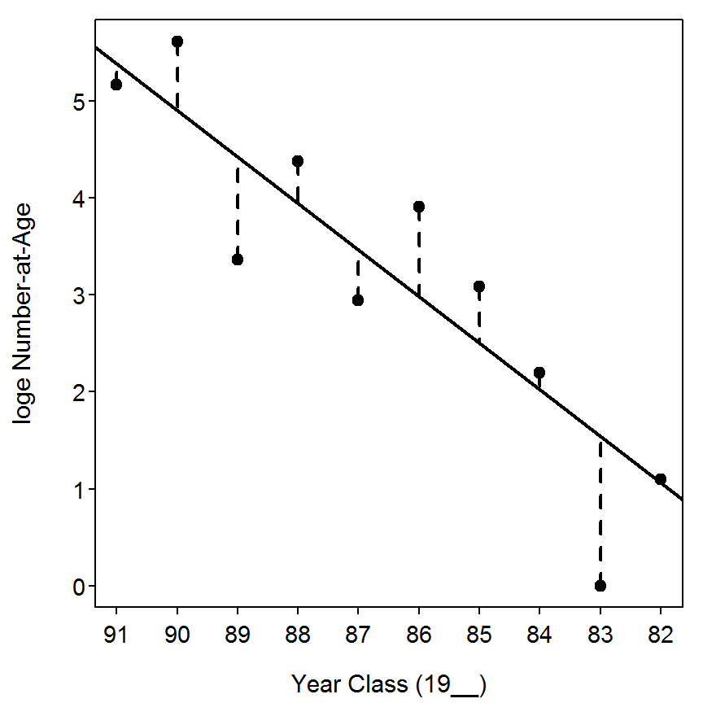

```r
> plot(lnum~age,data=d4,xlab="Year Class (19__)",xaxt="n", ylab="loge Number-at-Age",pch=19)
> axis(1,at=ycs$age,labels=ycs$yearcl)  # Add 'new' x-axis
> abline(lm2,lwd=2)                     # Add regression line
> for (i in 1:nrow(ycs)) {              # Add residual lines
    with(ycs,lines(c(age[i],age[i]),c(lnum[i],plnum[i]),lty=2,lwd=2))
  }
```

There are many other ways to show the year-class strength (i.e., studentized residuals). The two plots below are examples,

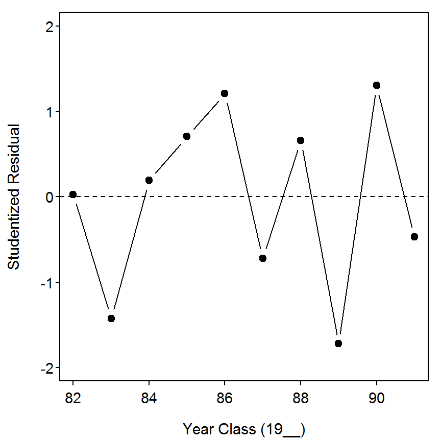

```r
> plot(sresid~yearcl,data=ycs,type="b",xlab="Year Class (19__)", ylab="Studentized Residual",
       pch=19,ylim=c(-2,2))
> abline(h=0,lty=2)                     # Add horizontal line at 0
```

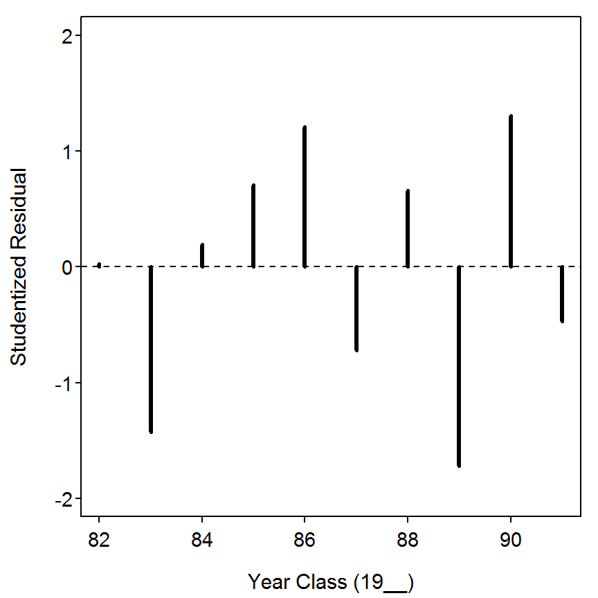

```r
> plot(sresid~yearcl,data=ycs,type="h",xlab="Year Class (19__)", ylab="Studentized Residual",
       pch=19,ylim=c(-2,2),lwd=3)
> abline(h=0,lty=2)
```

## 4.5 Use of Correlation, Simple Regression, and Multiple Regression Analyses to Explain Recruitment Variation

From the data presented in Table 4.1 (in text), the relations between C/f age-0 crappies (*Pomoxis* spp.) (`cpe0`) and reservoir hydrologic conditions were determined. The respective year-classes (`yearcl`) were also noted. The following R code plots bivariate relations between C/f of age-0 fish and hydrologic variables, computes the Pearson product moment correlation coefficients among age-0 catch and the reservoir hydrologic terms, and finally computes multiple regressions to describe and predict age-0 catch from these hydrologic variables.

### 4.5.1 Preparing Data

The [`box4_5.txt`](https://raw.githubusercontent.com/droglenc/aiffd2007/master/data/Box4_5.txt) data file is read and the structure of the data frame and the data frame is observed below.

```r
> d5 <- read.table("data/box4_5.txt",header=TRUE)
> str(d5)
```

```
'data.frame':   11 obs. of  6 variables:
 $ yearcl  : int  1989 1990 1991 1992 1993 1994 1995 1996 1997 1998 ...
 $ cpe0    : num  NA 8.03 0.47 0.61 1.38 2.73 1.66 9.89 1.86 3.72 ...
 $ cpe1    : num  3.12 5.32 0.39 0.97 3.59 2.61 0.57 8.63 0.93 1.17 ...
 $ winstage: num  171 172 171 171 171 ...
 $ winret  : num  7.2 4.2 7.4 6.6 6.2 5.9 6.8 5.5 6.1 5.6 ...
 $ sprstage: num  172 172 172 172 172 ...
```

```r
> d5
```

```
   yearcl cpe0 cpe1 winstage winret sprstage
1    1989   NA 3.12   170.85    7.2   171.79
2    1990 8.03 5.32   171.76    4.2   171.75
3    1991 0.47 0.39   170.73    7.4   171.75
4    1992 0.61 0.97   170.67    6.6   171.82
5    1993 1.38 3.59   170.99    6.2   171.77
6    1994 2.73 2.61   170.93    5.9   171.87
7    1995 1.66 0.57   170.88    6.8   171.80
8    1996 9.89 8.63   171.39    5.5   171.85
9    1997 1.86 0.93   170.83    6.1   171.90
10   1998 3.72 1.17   171.04    5.6   171.83
11   1999 2.18   NA   170.77    9.7   171.92
```

### 4.5.2 Summary Statistics and Plots

The summary statistics table is computed with `Summarize()`. One can use `lapply()` as shown below to compute the summary statistics for each variable in a data frame (NOTE: I excluded the `yearcl` and `cpe1` variables from the data frame for these summaries).

```r
> lapply(as.list(d5[,-c(1,3)]),Summarize,digits=4)
```

```
$cpe0
       n   nvalid     mean       sd      min       Q1   median       Q3
 11.0000  10.0000   3.2530   3.1838   0.4700   1.4500   2.0200   3.4720
     max percZero
  9.8900   0.0000

$winstage
       n   nvalid     mean       sd      min       Q1   median       Q3
 11.0000  11.0000 170.9855   0.3216 170.7000 170.8000 170.9000 171.0000
     max percZero
171.8000   0.0000

$winret
       n   nvalid     mean       sd      min       Q1   median       Q3
 11.0000  11.0000   6.4727   1.3907   4.2000   5.7500   6.2000   7.0000
     max percZero
  9.7000   0.0000

$sprstage
       n   nvalid     mean       sd      min       Q1   median       Q3
 11.0000  11.0000 171.8227   0.0578 171.8000 171.8000 171.8000 171.9000
     max percZero
171.9000   0.0000
```

The most efficient way to construct the plots described in the box is with `pairs()`. The `pairs()` function requires a formula as its first argument which must start with a tilde followed by the apparent summation of all numeric variables. The data frame in which the variables are found is included in the `data=` argument.

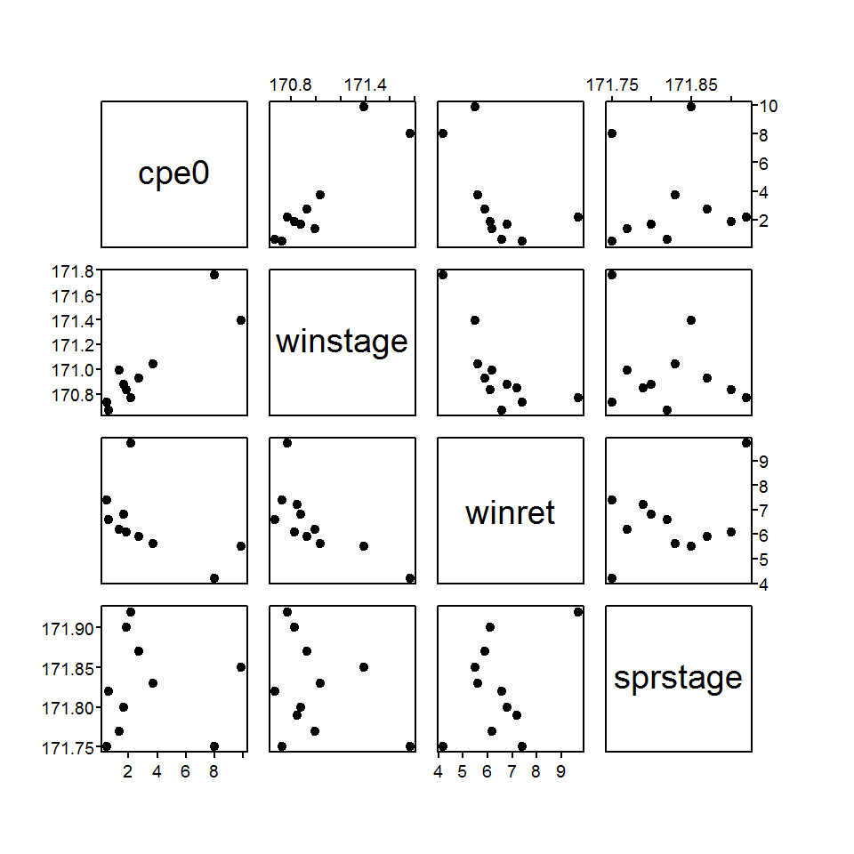

```r
> pairs(~cpe0+winstage+winret+sprstage,data=d5,pch=19)
```

From this analysis it appears that the CPE of age-0 fish is highly linearly related to mean winter stage level and mean winter retention (though, this may be curvilinear) and rather weakly related to mean spring stage (though, two potential outliers are evident). In addition, mean winter stage level and mean winter retention appear to be highly negatively correlated (though, potentially curvilinear).

### 4.5.3 Correlation Analysis

The authors examined the correlations, with p-values corresponding to a test of whether the correlation is equal to zero, between all variables. This computation is accomplished with `rcorr()` as described in Box 4.2.

```r
> rcorr(as.matrix(d5[,c("cpe0","winstage","winret","sprstage")]))
```

```
          cpe0 winstage winret sprstage
cpe0      1.00     0.89  -0.56    -0.03
winstage  0.89     1.00  -0.72    -0.29
winret   -0.56    -0.72   1.00     0.38
sprstage -0.03    -0.29   0.38     1.00

n
         cpe0 winstage winret sprstage
cpe0       10       10     10       10
winstage   10       11     11       11
winret     10       11     11       11
sprstage   10       11     11       11

P
         cpe0   winstage winret sprstage
cpe0            0.0005   0.0902 0.9297
winstage 0.0005          0.0126 0.3820
winret   0.0902 0.0126          0.2485
sprstage 0.9297 0.3820   0.2485
```

### 4.5.4 Multiple Linear Regressions

```r
> lm1 <- lm(cpe0~winstage+winret+sprstage,data=d5)
> summary(lm1)
```

```
Coefficients:
              Estimate Std. Error t value Pr(>|t|)
(Intercept) -4.238e+03  1.512e+03  -2.803  0.03103
winstage     9.615e+00  1.956e+00   4.914  0.00267
winret       8.491e-02  4.752e-01   0.179  0.86407
sprstage     1.511e+01  8.509e+00   1.776  0.12611

Residual standard error: 1.381 on 6 degrees of freedom
  (1 observation deleted due to missingness)
Multiple R-squared: 0.8746, Adjusted R-squared: 0.8119
F-statistic: 13.95 on 3 and 6 DF,  p-value: 0.004103
```

```r
> vif(lm1)
```

```
winstage   winret sprstage
2.036654 2.222351 1.224579
```

As the authors of the box suggest, `winret` is excluded from the analysis as it was highly correlated with `winstage` but `winstage` was more highly correlated with `cpe0`.

```r
> lm2 <- lm(cpe0~winstage+sprstage,data=d5)
> summary(lm2)
```

```
Coefficients:
             Estimate Std. Error t value Pr(>|t|)
(Intercept) -4273.241   1391.124  -3.072 0.018022
winstage        9.380      1.347   6.963 0.000219
sprstage       15.553      7.556   2.058 0.078563

Residual standard error: 1.282 on 7 degrees of freedom
  (1 observation deleted due to missingness)
Multiple R-squared: 0.874,  Adjusted R-squared: 0.8379
F-statistic: 24.27 on 2 and 7 DF,  p-value: 0.0007109
```

Finally, the simple linear regression with just `winstage` is fit.

```r
> lm3 <- lm(cpe0~winstage,data=d5)
> summary(lm3)
```

```
Coefficients:
             Estimate Std. Error t value Pr(>|t|)
(Intercept) -1445.158    257.907  -5.603 0.000508
winstage        8.470      1.508   5.616 0.000501

Residual standard error: 1.519 on 8 degrees of freedom
  (1 observation deleted due to missingness)
Multiple R-squared: 0.7977, Adjusted R-squared: 0.7724
F-statistic: 31.54 on 1 and 8 DF,  p-value: 0.0005008
```

### 4.5.5 Final Plot

The plot at the end of the box can be constructed in parts. The initial plot is constructed with `plot()` as usual. Year-class labels for each point are added with `thigmophobe.labels()` from the `plotrix` package which takes the x- and y-coordinates as the first two arguments and the labels as the third argument. I subtracted 1900 from each value in the `yearcl` variable so that only the two-digit year would be printed. The `thigmophobe.labels()` function positions the labels in a manner that reduces the chances of label overlap. The two uses of `abline()` are used to add a vertical line at the “Full Summer Pool” value and the best-fit line from the regression of age-0 CPE on mean winter stage.

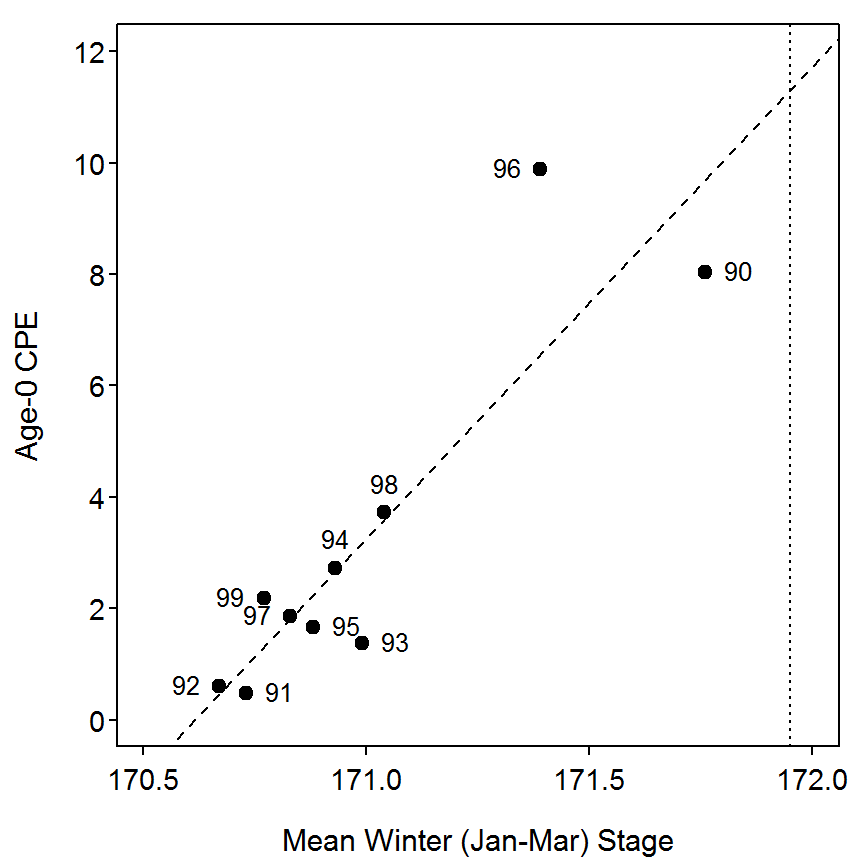

```r
> plot(cpe0~winstage,data=d5,pch=19,xlim=c(170.5,172),ylim=c(0,12),
       xlab="Mean Winter (Jan-Mar) Stage",ylab="Age-0 CPE")
> thigmophobe.labels(d5$winstage,d5$cpe0,d5$yearcl-1900,cex=0.8)
> abline(v=171.95,lty=3)
> abline(lm3,lty=2)
```

## 4.6 Incorporation of an Environmental Term into a Catch-Curve Regression to Explain Fluctuations in Recruitment

From the data presented in the R code in Box 4.4 and the code below, April-July retention will first be plotted against the residuals from the weighted catch-curve regression for largemouth bass. Then, this term will be added to the simple linear catch-curve regression to compute a multiple regression. The mean retention (`meanret`) between April-July corresponds to the hatching and post-hatching time period for each year-class when fish were age-0 (Maceina et al. 1995).

The same data and `ycs` data frame from Box 4.4 are used here.

### 4.6.1 Relating Year-Class Strength to Mean Retention Time

The plot of the residuals versus mean retention time (left) and log mean retention time (right) is constructed below. There is a clear curvilinear pattern evident in the raw residuals plot but not in the transformed plot (though a heteroscedasticity is evident). The relatively strong relationship between the residuals from the catch curve model and the log mean retention time suggests that including log mean retention time in the catch curve model may explain a significant portion of the remaining unexplained variability. This term is included in the analysis further below.

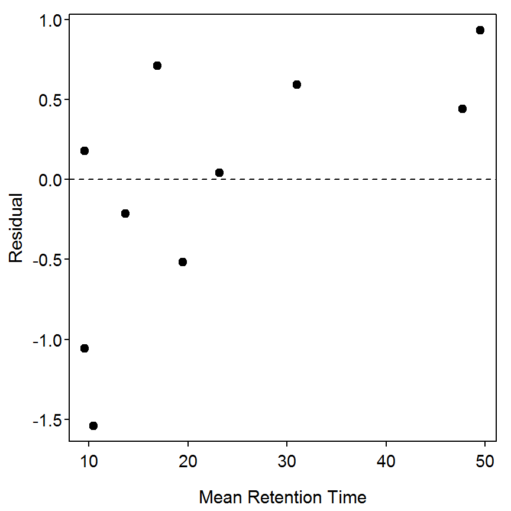

```r
> plot(resid~meanret,data=ycs,pch=19,xlab="Mean Retention Time", ylab="Residual")
> abline(h=0,lty=2)
```

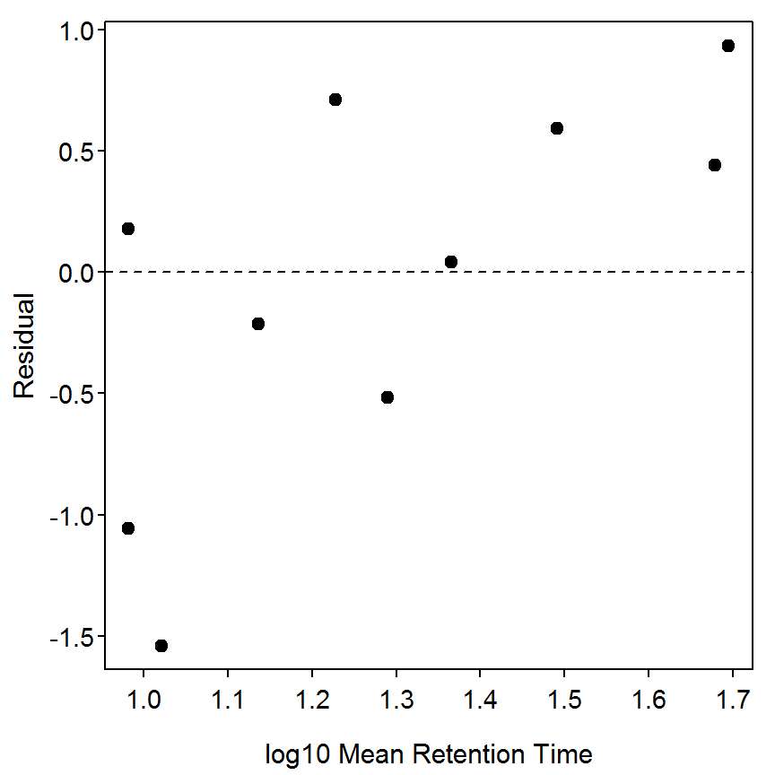

```r
> plot(resid~lmeanret,data=ycs,pch=19,xlab="log10 Mean Retention Time", ylab="Residual")
> abline(h=0,lty=2)
```

The multiple linear regression with the `lmeanret` variable is computed with `lm()` by “adding” the `lmeanret` to the original weighted catch curve model.

```r
> lm3 <- lm(lnum~age+lmeanret,weights=plnum1,data=d4)
> summary(lm3)
```

```
Coefficients:
            Estimate Std. Error t value Pr(>|t|)
(Intercept)  3.95057    1.00022   3.950 0.005534
age         -0.52606    0.07666  -6.862 0.000239
lmeanret     2.04888    0.77271   2.652 0.032867

Residual standard error: 1.072 on 7 degrees of freedom
Multiple R-squared: 0.8736, Adjusted R-squared: 0.8375
F-statistic:  24.2 on 2 and 7 DF,  p-value: 0.0007173
```

The summary statistics and correlation analyses shown in the box are constructed with

```r
> Summarize(ycs$resid,digits=4)
```

```
       n   nvalid     mean       sd      min       Q1   median       Q3
 10.0000  10.0000  -0.0437   0.7975  -1.5390  -0.4411   0.1084   0.5529
     max percZero
  0.9310   0.0000
```

```r
> Summarize(ycs$meanret,digits=4)
```

```
       n   nvalid     mean       sd      min       Q1   median       Q3
 10.0000  10.0000  23.1200  15.0095   9.6000  11.3000  18.2000  29.0500
     max percZero
 49.5000   0.0000
```

```r
> rcorr(cbind(ycs$resid,d4$meanret))
```

```
     [,1] [,2]
[1,] 1.00 0.66
[2,] 0.66 1.00

n= 10


P
     [,1]  [,2]
[1,]       0.039
[2,] 0.039
```

## 4.7 Computation of the Beverton-Holt Recruit-Spawning Curve

### 4.7.1 Preparing Data

The [`box4_7.txt`](https://raw.githubusercontent.com/droglenc/aiffd2007/master/data/Box4_7.txt) data file is read and the structure of the data frame is observed below. In addition, the authors of the box created a new variable that contains the natural log of the number of recruits.

```r
> d7 <- read.table("data/box4_7.txt",header=TRUE)
> str(d7)
```

```
'data.frame':   18 obs. of  4 variables:
 $ lake   : Factor w/ 3 levels "AL","DE","JB": 1 1 1 1 1 1 2 2 2 2 ...
 $ year   : int  91 92 93 94 95 96 92 93 94 95 ...
 $ spawner: int  340 907 171 1040 55 524 213 1034 457 200 ...
 $ recruit: num  5.41 3 2.41 2.25 0.41 8.71 1.13 4.66 1.94 7.28 ...
```

```r
> d7$lrecruit <- log(d7$recruit)
```

### 4.7.2 Plot of Stock-Recruit Data

The plot, mentioned but not shown in the box, is constructed as shown below.

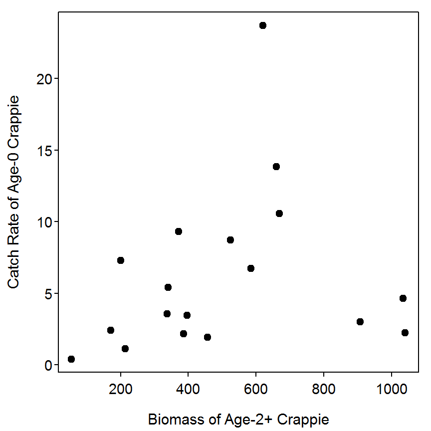

```r
> plot(recruit~spawner,data=d7,ylab="Catch Rate of Age-0 Crappie",
       xlab="Biomass of Age-2+ Crappie",pch=19)
```

### 4.7.3 Non-Linear Model Fit with Additive Errors (i.e., Raw Data)

The non-linear model fitting procedure in R is implemented with `nls()`, which requires the model formula, the list of starting values, and the data frame containing the variables as arguments. In addition, `trace=TRUE` can be included in `nls()` to see the residual sum-of-squares and current values of the parameters for each iteration of the fitting process. For simplicity and clarity, the starting values can be entered into a list and the formula corresponding to the Beverton-Holt stock-recruit model are created prior to calling `nls()`. The parameter estimates and correlation among parameters are extracted from the saved `nls()` object with `overview()` from the `nlstools` package.

```r
> bhst <- list(a=0.03,b=0.002)                     # list of starting values
> bhsr <- recruit~(a*spawner)/(1+b*spawner)        # B-H model as an R formula
> nls1 <- nls(bhsr,data=d7,start=bhst,trace=TRUE)
```

```
502.8573 :  0.030 0.002
486.2032 :  0.041785368 0.003879117
484.4992 :  0.037706303 0.003577408
484.485 :  0.039117234 0.003767486
484.4819 :  0.038257852 0.003643063
484.4802 :  0.038831928 0.003725968
484.4796 :  0.038454230 0.003671472
484.4793 :  0.038704677 0.003707628
484.4792 :  0.038539434 0.003683781
484.4791 :  0.038648837 0.003699574
484.4791 :  0.038576567 0.003689143
484.4791 :  0.038624375 0.003696044
484.4791 :  0.038592774 0.003691483
484.4791 :  0.03861368 0.00369450
484.4791 :  0.038599860 0.003692506
484.4791 :  0.038608998 0.003693825
484.4791 :  0.038602954 0.003692952
484.4791 :  0.038606952 0.003693529
484.4791 :  0.038604309 0.003693148
```

```r
> overview(nls1)
```

```
------
Formula: recruit ~ (a * spawner)/(1 + b * spawner)

Parameters:
  Estimate Std. Error t value Pr(>|t|)
a 0.038604   0.047423   0.814    0.428
b 0.003693   0.006752   0.547    0.592

Residual standard error: 5.503 on 16 degrees of freedom

Number of iterations to convergence: 18
Achieved convergence tolerance: 9.341e-06

------
Residual sum of squares: 484

------
t-based confidence interval:
         2.5%      97.5%
a -0.06192736 0.13913598
b -0.01062148 0.01800778

------
Correlation matrix:
          a         b
a 1.0000000 0.9864924
b 0.9864924 1.0000000
```

### 4.7.4 Non-Linear Model Fit with Multiplicative Errors (i.e., Log Transformed Data)

The Beverton-Holt model with multiplicative errors is fit similarly with the only major adjustment being that the both sides of the model are log-transformed.

```r
> bhst2 <- list(a=0.01,b=0.002)
> bhsr2 <- lrecruit~log((a*spawner)/(1+b*spawner))
> nls2 <- nls(bhsr2,data=d7,start=bhst2)
> overview(nls2)
```

```
------
Formula: lrecruit ~ log((a * spawner)/(1 + b * spawner))

Parameters:
  Estimate Std. Error t value Pr(>|t|)
a 0.016980   0.009339   1.818   0.0878
b 0.001423   0.001918   0.742   0.4688

Residual standard error: 0.7957 on 16 degrees of freedom

Number of iterations to convergence: 10
Achieved convergence tolerance: 7.649e-06

------
Residual sum of squares: 10.1

------
t-based confidence interval:
          2.5%       97.5%
a -0.002818814 0.036778136
b -0.002642872 0.005489538

------
Correlation matrix:
          a         b
a 1.0000000 0.9400708
b 0.9400708 1.0000000
```

### 4.7.5 Bootstrapping Confidence Intervals

The `nlsBoot()` from the `nlstools` package is used to bootstrap the residuals from a non-linear model fit. This function only requires the model as an argument, but the number of bootstrap samples can be controlled with the `niter=` argument. The mean parameter values and confidence intervals are constructed from the saved `nlsBoot` object using `summary()`.

```r
> bhbc <- nlsBoot(nls2,niter=2000)
> summary(bhbc)
```

```
------
Bootstrap statistics
     Estimate Std. error
a 0.027006261 0.04774726
b 0.003720517 0.01088564

------
Median of bootstrap estimates and percentile confidence intervals
       Median         2.5%      97.5%
a 0.018311724 8.933571e-03 0.08917533
b 0.001691925 4.157789e-05 0.01744845
```

### 4.7.6 Diagnostics

The predicted number of log recruits from the multiplicative errors model is computed with `fitted()` and the residuals are computed with `residuals()`. These two items are appended to the data frame and the residuals are summed below.

```r
> d7$pred.lrec <- fitted(nls2)
> d7$res.lrec <- residuals(nls2)
> d7
```

```
   lake year spawner recruit   lrecruit  pred.lrec    res.lrec
1    AL   91     340    5.41  1.6882491  1.3585103  0.32973876
2    AL   92     907    3.00  1.0986123  1.9054310 -0.80681870
3    AL   93     171    2.41  0.8796267  0.8480830  0.03154377
4    AL   94    1040    2.25  0.8109302  1.9628708 -1.15194063
5    AL   95      55    0.41 -0.8915981 -0.1437761 -0.74782197
6    AL   96     524    8.71  2.1644718  1.6285244  0.53594735
7    DE   92     213    1.13  0.1222176  1.0207533 -0.89853571
8    DE   93    1034    4.66  1.5390154  1.9605340 -0.42151858
9    DE   94     457    1.94  0.6626880  1.5478883 -0.88520030
10   DE   95     200    7.28  1.9851309  0.9720790  1.01305184
11   DE   96     669   10.56  2.3570733  1.7610829  0.59599034
12   JB   90     372    9.33  2.2332350  1.4182270  0.81500803
13   JB   91     386    2.19  0.7839015  1.4422262 -0.65832470
14   JB   92     585    6.75  1.9095425  1.6901098  0.21943273
15   JB   93     660   13.85  2.6282852  1.7541221  0.87416311
16   JB   94     337    3.58  1.2753628  1.3525293 -0.07716648
17   JB   95     396    3.48  1.2470323  1.4586587 -0.21162642
18   JB   96     620   23.70  3.1654750  1.7213974  1.44407761
```

```r
> sum(d7$res.lrec)
```

```
[1] 2.254291e-08
```

The simple linear regression of the predicted number of log recruits on the observed number of log recruits is fit and the anova table and coefficients are extracted below.

```r
> lm1 <- lm(pred.lrec~lrecruit,data=d7)
> anova(lm1)
```

```
          Df Sum Sq Mean Sq F value   Pr(>F)
lrecruit   1 1.6680 1.66803  9.7105 0.006651
Residuals 16 2.7484 0.17178
Total     17 4.4164
```

```r
> summary(lm1)
```

```
Coefficients:
            Estimate Std. Error t value Pr(>|t|)
(Intercept)   0.9662     0.1768   5.464  5.2e-05
lrecruit      0.3222     0.1034   3.116  0.00665

Residual standard error: 0.4145 on 16 degrees of freedom
Multiple R-squared: 0.3777, Adjusted R-squared: 0.3388
F-statistic:  9.71 on 1 and 16 DF,  p-value: 0.006651
```

### 4.7.7 Final Fitted Plot

Finally, a plot that shows the raw data with fitted lines from the two non-linear fits can be constructed as shown below. In this code, a plot of the data is constructed first, the coefficients of the first model are extracted with `coef()` and saved, and those coefficients are used in `curve()` to add the model curve on to the plot. This is repeated for the second model and a legend is added in the top-left corner of the plot.

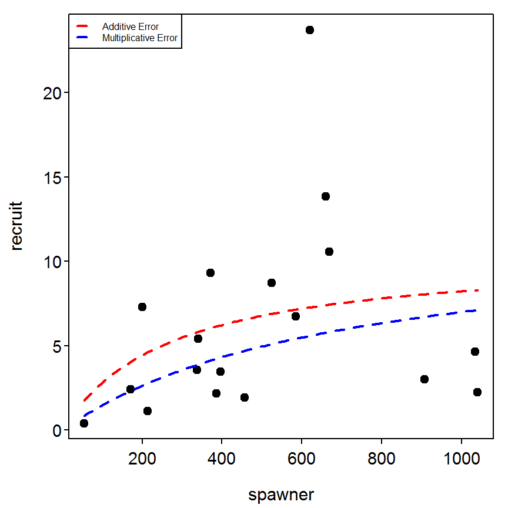

```r
> plot(recruit~spawner,data=d7,pch=19)
> cnls1 <- coef(nls1)
> curve((cnls1[1]*x)/(1+cnls1[2]*x),from=min(d7$spawner),to=max(d7$spawner),col="red",
        lwd=2,lty=2,add=TRUE)
> cnls2 <- coef(nls2)
> curve((cnls2[1]*x)/(1+cnls2[2]*x),from=min(d7$spawner),to=max(d7$spawner),col="blue",
        lwd=2,lty=2,add=TRUE)
> legend("topleft",legend=c("Additive Error","Multiplicative Error"),col=c("red","blue"),
         lwd=2,lty=2,cex=0.5)
```

## 4.8 Computation of Ricker Recruit-Spawner Curves with the Inclusion of an Environmental Term to Explain Recruit Variation

Population estimates for age-5 and older adult walleye (*Sander vitreus*) (spawner) and age-0 walleye (recruit) were made in Escanaba Lake, Wisconsin, from 1958 to 1991 (data from Hansen et al. (1998); see Table 4.3 in text). The following R code computes a nonlinear regression to describe the relation between recruits and spawners assuming lognormal error structure (equation [4.6] in text). From this regression, predicted recruits are regressed against observed recruits to provide additional statistical inference. Next the program computes the Ricker recruit-spawner relation (equation [4.7] in text) using linear regression. The corrected coefficient of determination and associated F-statistic was given by regressing predicted recruits against observed recruits. Finally, the program also computes the nonlinear regression with lognormal error structure in the recruit-spawner relation to include the variation in May air temperature (`mtempcv`) as an additional regressor of walleye recruits (equation [4.9] in text modified to include lognormal error structure).

### 4.8.1 Preparing Data

The [`box4_8.txt`](https://raw.githubusercontent.com/droglenc/aiffd2007/master/data/Box4_8.txt) data file is read and the structure of the data frame is observed below. The analyses below require a variable that is the natural log of the number of recruits, natural log of the number of spawners, the ratio of recruits to spawners, and the log of this ratio. These variables are created and added to the data frame.

```r
> d8 <- read.table("data/box4_8.txt",header=TRUE)
> str(d8)
```

```
'data.frame':   34 obs. of  4 variables:
 $ year   : int  1958 1959 1960 1961 1962 1963 1964 1965 1966 1967 ...
 $ recruit: int  4532 22996 628 879 14747 13205 31793 10621 22271 8736 ...
 $ spawner: int  775 2310 2990 1400 1130 790 1195 981 870 1104 ...
 $ mtempcv: num  0.241 0.163 0.461 0.33 0.226 ...
```

```r
> d8$logR <- log(d8$recruit)
> d8$logS <- log(d8$spawner)
> d8$ratio <- d8$recruit/d8$spawner
> d8$lratio <- log(d8$ratio)
> view(d8)
```

```
   year recruit spawner mtempcv      logR     logS     ratio    lratio
7  1964   31793    1195 0.19229 10.367001 7.085901 26.605021 3.2811000
12 1969   18885    1421 0.17799  9.846123 7.259116 13.289937 2.5870071
15 1972    1697    1354 0.39461  7.436617 7.210818  1.253323 0.2257988
18 1975    1932     962 0.33459  7.566311 6.869014  2.008316 0.6972966
21 1978    5334    1945 0.32837  8.581857 7.573017  2.742416 1.0088394
28 1985   14599     394 0.12269  9.588708 5.976351 37.053299 3.6123574
```

### 4.8.2 Plot of Stock-Recruit Data

I wanted to visualize the stock-recruit relationship before fitting any models in two different ways. I first plotted the stock-recruit plot with year labels next to each point. The year labels for each point are added with `thigmophobe.labels()` as described in Box 4.5. I then plotted the stock-recruit plot but with the size of each plotted point relative to the value of the `mtempcv` variable. This plotting requires use of the “character expansion” (i.e., `cex=`) argument in `plot()`. The default character size is 1 such that, for example, a `cex=2` value would produce a point twice as big as typical. I rescaled (with `rescale()` from the `plotrix` package) the `mtempcv` variable to take values between 0.5 and 2 so that relatively small values of `mtempcv` would produce smaller points and relatively larger values of `mtempcv` would produce larger points. It is apparent from these plots that the stock-recruit relationship is weak and that there may be a very weak relationship with the variation in May temperatures (it seems that lower recruitment may correspond to higher temperature variability).

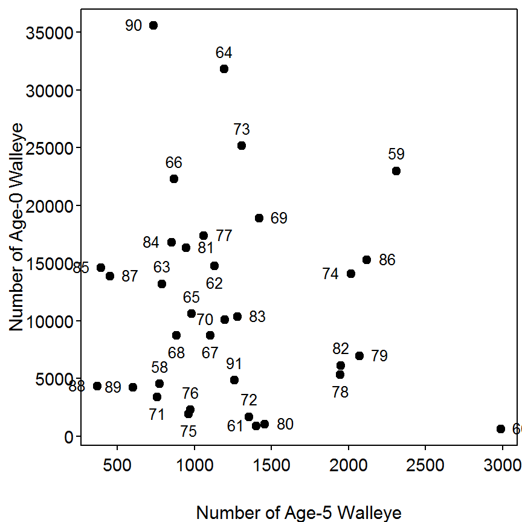

```r
> plot(recruit~spawner,data=d8,ylab="Number of Age-0 Walleye",
       xlab="Number of Age-5 Walleye",pch=19)
> with(d8,thigmophobe.labels(spawner,recruit,labels=year-1900,cex=0.8))
```

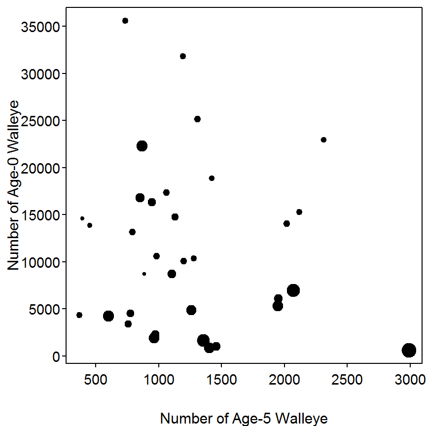

```r
> plot(recruit~spawner,data=d8,ylab="Number of Age-0 Walleye",
       xlab="Number of Age-5 Walleye",pch=19,cex=rescale(mtempcv,c(0.5,2)))
```

### 4.8.3 Ricker Model - Nonlinear Regression with Multiplicative Errors

The non-linear model fitting procedure in R is implemented with `nls()` as described in Box 4.7. The model is fit with multiplicative errors if both the sides of the formula are log-transformed.

```r
> rst <- list(a=4,b=0)                           # Starting values
> rsr <- logR~log(spawner*exp(a+b*spawner))      # Ricker model as an R formula
> nls1 <- nls(rsr,data=d8,start=rst,trace=TRUE)
```

```
193.9594 :  4 0
33.79315 :   3.391569209 -0.001176262
```

```r
> overview(nls1)
```

```
------
Formula: logR ~ log(spawner * exp(a + b * spawner))

Parameters:
    Estimate Std. Error t value Pr(>|t|)
a  3.3915692  0.4117562   8.237 2.08e-09
b -0.0011763  0.0003018  -3.898 0.000467

Residual standard error: 1.028 on 32 degrees of freedom

Number of iterations to convergence: 1
Achieved convergence tolerance: 5.208e-10

------
Residual sum of squares: 33.8

------
t-based confidence interval:
          2.5%         97.5%
a  2.552849366  4.2302890519
b -0.001790988 -0.0005615366

------
Correlation matrix:
           a          b
a  1.0000000 -0.9037713
b -0.9037713  1.0000000
```

The predicted number of log recruits and the residuals from the multiplicative errors model are appended to the original data frame and the sum of the residuals is shown to be equal to zero.

```r
> d8$pred1.lrec <- fitted(nls1)
> d8$res1.lrec <- residuals(nls1)
> sum(d8$res1.lrec)
```

```
[1] -4.438914e-08
```

The simple linear regression of the predicted number of log recruits on the observed number of log recruits is fit with `lm()` and `summary()` is used to extract the model coefficients and, as illustrated in the box, the $R^{2}$ value for the non-linear model fit.

```r
> lm1 <- lm(pred1.lrec~logR,data=d8)
> summary(lm1)
```

```
Coefficients:
            Estimate Std. Error t value Pr(>|t|)
(Intercept)  8.35871    0.40507  20.635   <2e-16
logR         0.06577    0.04498   1.462    0.153

Residual standard error: 0.27 on 32 degrees of freedom
Multiple R-squared: 0.06263,    Adjusted R-squared: 0.03334
F-statistic: 2.138 on 1 and 32 DF,  p-value: 0.1534
```

### 4.8.4 Ricker Model – Linear Regression

The Ricker model can be linearized via transformation as described in the AIFFD book. This linearized version of the model is fit and summarized below. The predicted number of log recruits from the linear model is a bit more difficult to obtain because this model predicts the log ratio of recruits to spawners. Thus, these predictions should be back-transformed to the original scale (i.e., the ratio), multiplied by the number of spawners to get the predicted number of recruits, and then logged to get the predicted log number of recruits. This process of computing predicted log number of recruits is shown below followed by the regression of of these predictions on the observed log recruits and the summary of that model fit.

```r
> lm2 <- lm(lratio~spawner,data=d8)
> summary(lm2)
```

```
Coefficients:
              Estimate Std. Error t value Pr(>|t|)
(Intercept)  3.3915692  0.4117562   8.237 2.08e-09
spawner     -0.0011763  0.0003018  -3.898 0.000467

Residual standard error: 1.028 on 32 degrees of freedom
Multiple R-squared: 0.3219, Adjusted R-squared: 0.3007
F-statistic: 15.19 on 1 and 32 DF,  p-value: 0.0004665
```

```r
> d8$pred2.lrec <- log(exp(fitted(lm2))*d8$spawner)
> lm2a <- lm(pred2.lrec~logR,data=d8)
> summary(lm2a)
```

```
Coefficients:
            Estimate Std. Error t value Pr(>|t|)
(Intercept)  8.35871    0.40507  20.635   <2e-16
logR         0.06577    0.04498   1.462    0.153

Residual standard error: 0.27 on 32 degrees of freedom
Multiple R-squared: 0.06263,    Adjusted R-squared: 0.03334
F-statistic: 2.138 on 1 and 32 DF,  p-value: 0.1534
```

### 4.8.5 Ricker Model with Environmental Component - Nonlinear Regression with Lognormal Errors

In this analysis the authors return to the original nonlinear model but include the variation in May temperatures variable (i.e., `mtempcv`) as another potential prediction of the number of recruits. The model fit and summary extraction is essential as before with the exception that there is an additional variable and parameter in the model.

```r
> rst2 <- list(a=4,b=0,c=-7)
> rsr2 <- logR~log(spawner*exp(a+b*spawner+c*mtempcv))
> nls2 <- nls(rsr2,data=d8,start=rst2,trace=TRUE)
```

```
32.5687 :   4  0 -7
21.99897 :   4.7915401817 -0.0007299359 -7.8388472553
```

```r
> overview(nls2)
```

```
------
Formula: logR ~ log(spawner * exp(a + b * spawner + c * mtempcv))

Parameters:
    Estimate Std. Error t value Pr(>|t|)
a  4.7915402  0.4815157   9.951  3.6e-11
b -0.0007299  0.0002705  -2.698 0.011181
c -7.8388473  1.9228196  -4.077 0.000295

Residual standard error: 0.8424 on 31 degrees of freedom

Number of iterations to convergence: 1
Achieved convergence tolerance: 4.898e-09

------
Residual sum of squares: 22

------
t-based confidence interval:
           2.5%         97.5%
a   3.809482450  5.7735979130
b  -0.001281694 -0.0001781775
c -11.760463746 -3.9172307647

------
Correlation matrix:
           a          b          c
a  1.0000000 -0.2907282 -0.7131731
b -0.2907282  1.0000000 -0.4046843
c -0.7131731 -0.4046843  1.0000000
```

```r
> d8$pred3.lrec <- fitted(nls2)
> d8$res3.lrec <- residuals(nls2)
> sum(d8$res2.lrec)
```

```
[1] 0
```

```r
> lm4 <- lm(pred3.lrec~logR,data=d8)
> summary(lm4)
```

```
Coefficients:
            Estimate Std. Error t value Pr(>|t|)
(Intercept)  5.46530    0.77538   7.049 5.43e-08
logR         0.38916    0.08609   4.520 7.97e-05

Residual standard error: 0.5169 on 32 degrees of freedom
Multiple R-squared: 0.3897, Adjusted R-squared: 0.3706
F-statistic: 20.43 on 1 and 32 DF,  p-value: 7.968e-05
```

The relative significance of the `mtempcv` variable can be assessed by computing the SS explained by using model `nls2` as compared to `nls1` (this is the idea suggested by the authors of the box when they mentioned Montgomery and Peck (1982)). This comparison is constructed in R by submitting these two non-`lm()` objects to `anova()`.

```r
> anova(nls1,nls2)
```

```
  Res.Df Res.Sum Sq Df Sum Sq F value   Pr(>F)
1     32     33.793
2     31     21.999  1 11.794   16.62 0.000295
```

```r
> AIC(nls1,nls2)
```

```
     df       AIC
nls1  3 102.28034
nls2  4  89.68541
```

### 4.8.6 Final Fitted Plot

Finally, a plot that shows the raw data with fitted lines from the non-linear fits without the environmental variable and assuming multiplicative (i.e., `nls1`) and additive (computed below) errors is constructed below. This code follows the same concept as that described at the end of Box 4.7.

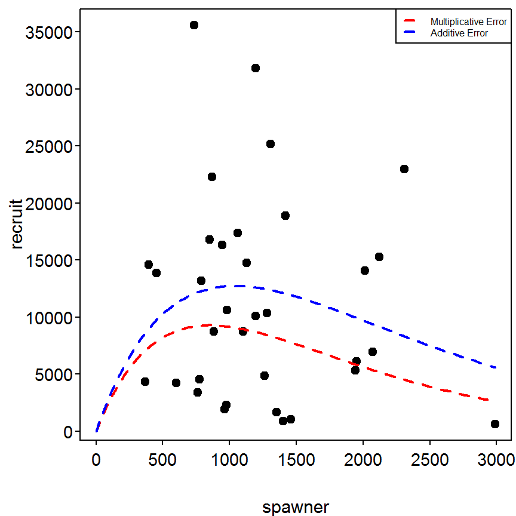

```r
> rsr3 <- recruit~spawner*exp(a+b*spawner)
> nls3 <- nls(rsr3,data=d8,start=rst)
> plot(recruit~spawner,data=d8,pch=19,xlim=c(0,max(d8$spawner)))
> cnls1 <- coef(nls1)
> curve(x*exp(cnls1[1]+cnls1[2]*x),from=0,to=max(d8$spawner),col="red",lwd=2,lty=2,add=TRUE)
> cnls3 <- coef(nls3)
> curve(x*exp(cnls3[1]+cnls3[2]*x),from=0,to=max(d8$spawner),col="blue",lwd=2,lty=2,add=TRUE)
> legend("topright",legend=c("Multiplicative Error","Additive Error"),col=c("red","blue"),
         lwd=2,lty=2,cex=0.5)
```

## 4.9 Computation of Bootstrapped Parameter Estimates for the Ricker Recruit-Spawner Curve

The same data used in Box 4.8 is used in this section.

### 4.9.1 Ricker Model - Nonlinear Regression with Multiplicative Errors

The Ricker model with multiplicative errors was fit in Box 4.8. This fitting is repeated below but the specific description of the methodology is not repeated.

```r
> d8$logR <- log(d8$recruit)
> rst <- list(a=4,b=0)
> rsr <- logR~log(spawner*exp(a-b*spawner))
> nls1 <- nls(rsr,data=d8,start=rst)
> overview(nls1)
```

```
------
Formula: logR ~ log(spawner * exp(a - b * spawner))

Parameters:
   Estimate Std. Error t value Pr(>|t|)
a 3.3915692  0.4117562   8.237 2.08e-09
b 0.0011763  0.0003018   3.898 0.000467

Residual standard error: 1.028 on 32 degrees of freedom

Number of iterations to convergence: 1
Achieved convergence tolerance: 4.887e-09

------
Residual sum of squares: 33.8

------
t-based confidence interval:
          2.5%       97.5%
a 2.5528493665 4.230289052
b 0.0005615366 0.001790988

------
Correlation matrix:
          a         b
a 1.0000000 0.9037713
b 0.9037713 1.0000000
```

### 4.9.2 Bootstrapping - Basic Analyses

The `nlsBoot()` function as described in Box 4.7 is used to bootstrap the residuals from a non-linear model fit. The `summary()` function can be used to extract the median values and 95% confidence intervals for each parameter from the bootstrap samples by submitting just the `nlsBoot` object. The `confint()` function extracts just the confidence intervals for each parameter and allows the user to choose a level of confidence with the optional `conf.level=` argument.

```r
> rbc <- nlsBoot(nls1,niter=2000)
> summary(rbc)
```

```
------
Bootstrap statistics
     Estimate   Std. error
a 3.393918490 0.3937028325
b 0.001175819 0.0002918835

------
Median of bootstrap estimates and percentile confidence intervals
       Median         2.5%       97.5%
a 3.385565304 2.6296306151 4.163318790
b 0.001167843 0.0006253082 0.001754622
```

```r
> confint(rbc)                  # default 95% CI
```

```
       95% LCI     95% UCI
a 2.6296306151 4.163318790
b 0.0006253082 0.001754622
```

```r
> confint(rbc,conf.level=0.9)   # illustrative 90% CI
```

```
       90% LCI     90% UCI
a 2.7458150964 4.036147593
b 0.0007177558 0.001665995
```

### 4.9.3 Bootstrapping - Further Analyses

The parameter estimates for each bootstrap sample are contained in the `coefboot` matrix object of the saved `nlsBoot()` object as illustrated below.

```r
> str(rbc)
```

```
List of 4
 $ coefboot: num [1:2000, 1:2] 3.39 2.95 4.64 3.86 3.5 ...
  ..- attr(*, "dimnames")=List of 2
  .. ..$ : NULL
  .. ..$ : chr [1:2] "a" "b"
 $ rse     : num [1:2000] 1.029 0.821 0.873 1.064 0.959 ...
 $ bootCI  : num [1:2, 1:3] 3.385565 0.001168 2.629631 0.000625 4.163319 ...
  ..- attr(*, "dimnames")=List of 2
  .. ..$ : chr [1:2] "a" "b"
  .. ..$ : chr [1:3] "Median" "2.5%" "97.5%"
 $ estiboot: num [1:2, 1:2] 3.393918 0.001176 0.393703 0.000292
  ..- attr(*, "dimnames")=List of 2
  .. ..$ : chr [1:2] "a" "b"
  .. ..$ : chr [1:2] "Estimate" "Std. error"
 - attr(*, "class")= chr "nlsBoot"
```

```r
> view(rbc$coefboot)
```

```
            a           b
[1,] 3.996118 0.001726619
[2,] 3.506436 0.001433546
[3,] 3.315255 0.001219446
[4,] 3.407417 0.001183765
[5,] 2.853613 0.000803138
[6,] 2.464638 0.000492226
```

```r
> rbc.d <- as.data.frame(rbc$coefboot)
> Summarize(rbc.d$a)
```

```
           n       nvalid         mean           sd          min           Q1
2000.0000000 2000.0000000    3.3939185    0.3937028    2.1270000    3.1320000
      median           Q3          max     percZero
   3.3860000    3.6750000    4.6420000    0.0000000
```

```r
> Summarize(rbc.d$b)
```

```
         n     nvalid       mean         sd        min         Q1     median
2.0000e+03 2.0000e+03 1.1758e-03 2.9190e-04 2.8930e-04 9.6920e-04 1.1680e-03
        Q3        max   percZero
1.3790e-03 2.1590e-03 0.0000e+00
```

```r
> t.test(rbc.d$a)
```

```
One Sample t-test with rbc.d$a
t = 385.5208, df = 1999, p-value < 2.2e-16
alternative hypothesis: true mean is not equal to 0
95 percent confidence interval:
 3.376654 3.411183
sample estimates:
mean of x
 3.393918
```

```r
> t.test(rbc.d$b)
```

```
One Sample t-test with rbc.d$b
t = 180.1549, df = 1999, p-value < 2.2e-16
alternative hypothesis: true mean is not equal to 0
95 percent confidence interval:
 0.001163019 0.001188619
sample estimates:
  mean of x
0.001175819
```

The quantiles presented in the box are constructed with `quantile()` include the vector of probabilities in the `probs=` argument.

```r
> quantile(rbc.d$a,probs=c(0,1,5,10,25,50,75,90,95,99,100)/100)
```

```
      0%       1%       5%      10%      25%      50%      75%      90%
2.127056 2.464483 2.745815 2.887022 3.131924 3.385565 3.674882 3.902363
     95%      99%     100%
4.036148 4.328816 4.642484
```

```r
> quantile(rbc.d$b,probs=c(0,1,5,10,25,50,75,90,95,99,100)/100)
```

```
          0%           1%           5%          10%          25%          50%
0.0002893182 0.0005091121 0.0007177558 0.0008084656 0.0009691694 0.0011678427
         75%          90%          95%          99%         100%
0.0013792831 0.0015567731 0.0016659945 0.0018392287 0.0021594678
```

Histograms, with some modifications, of a set of parameter estimates is created with `hist()`.

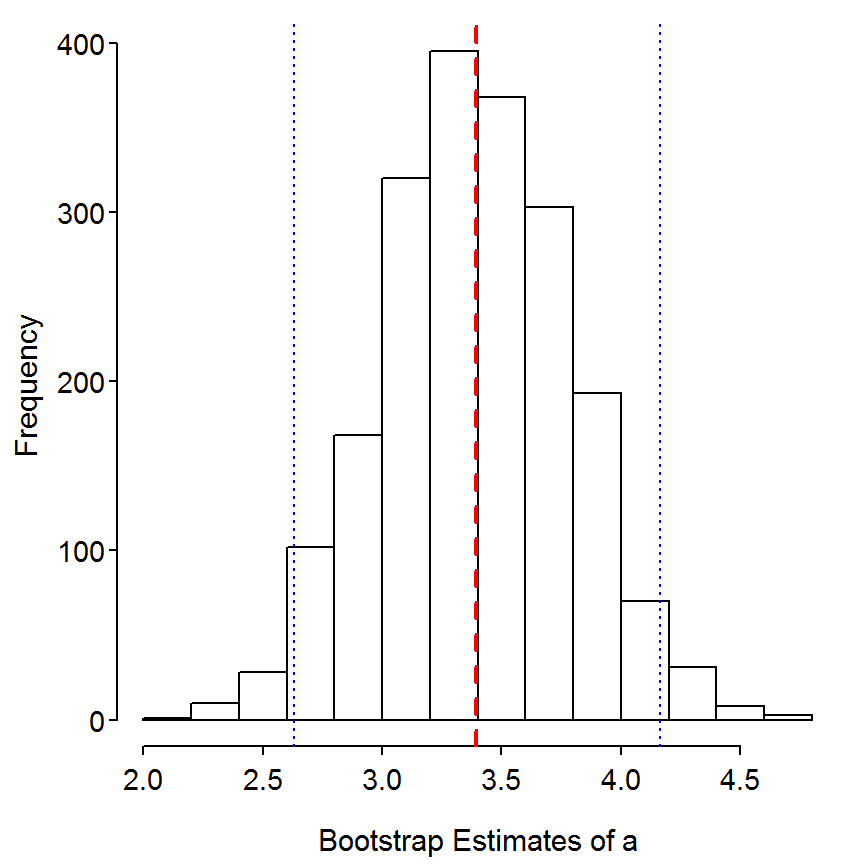

```r
> hist(rbc.d$a,xlab="Bootstrap Estimates of a",main="")
> abline(v=coef(nls1)["a"],lty=2,lwd=2,col="red")       # put nls estimate on hist
> abline(v=confint(rbc)["a",],lty=3,col="blue")         #   and bootstrap CIs
```

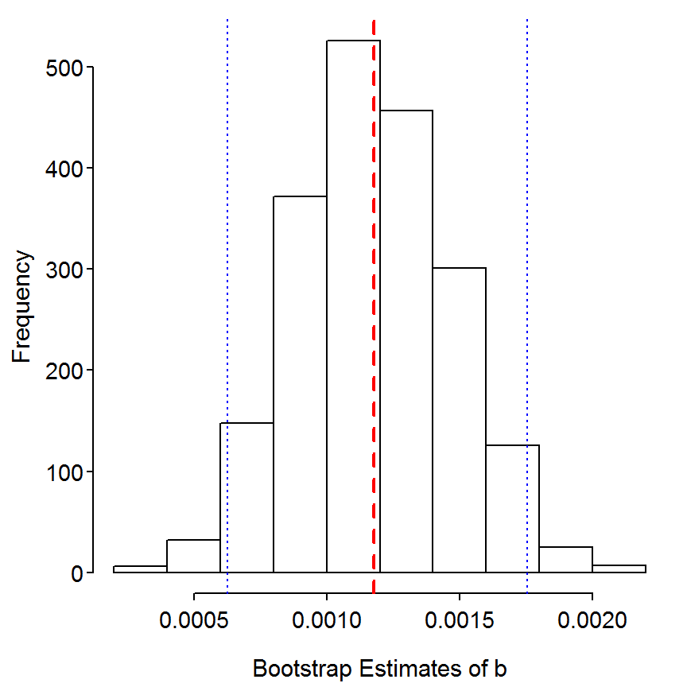

```r
> hist(rbc.d$b,xlab="Bootstrap Estimates of b",main="")
> abline(v=coef(nls1)["b"],lty=2,lwd=2,col="red")       # put nls estimate on hist
> abline(v=confint(rbc)["b",],lty=3,col="blue")         #   and bootstrap CIs
```

Finally, simply submitting the `nlsBoot` object to `plot` will produce a scatterplot of each pair of parameters from all bootstrap samples.

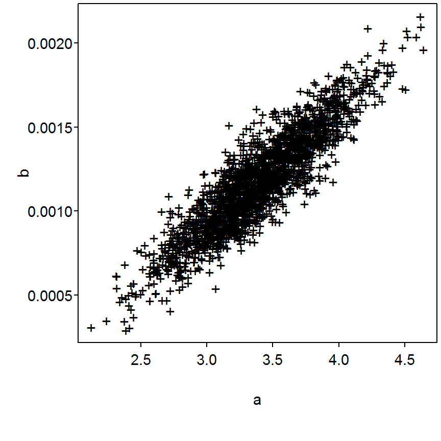

[output not shown]

```r
> plot(rbc)
```

References

Bettoli, P. W., and L. E. Miranda. 2001. A cautionary note about estimating mean length at age with subsampled data. North American Journal of Fisheries Management 21:425–428.

Hansen, M. J., M. A. Bozek, J. R. Newby, S. P. Newman, and M. D. Staggs. 1998. Factors affecting recruitment of walleyes in Escanaba Lake, Wisconsin, 1958-1996. North American Journal of Fisheries 125:831–843.

Kimura, D. K. 1988. Analyzing relative abundance indices with log-linear models. Transactions of the American Fisheries Society 8:175–180.

Maceina, M. J., and P. W. Bettoli. 1998. Variation in largemouth bass recruitment in four mainstream impoundments on the Tennessee River. North American Journal of Fisheries Management 18:998–1003.

Maceina, M. J., P. W. Bettoli, and D. R. Devries. 1994. Use of a split-plot analysis of variance design for repeated-measures fishery data. Fisheries 19(3):14–20.

Maceina, M. J., S. J. Rider, and S. T. Szedlmayer. 1995. Density, temporal spawning patterns, and growth of age-0 and age-1 largemouth bass (*Micropterus salmoides*) in vegetated and unvegetated areas of Lake Guntersville, Alabama. Pages 497–511 *in* D. C. Secor, J. M. Dean, and S. E. Campana, editors. Recent developments in fish otolith research. University of South Carolina Press, Columbia.

Madenjian, D. P., R. L. Knight, M. T. Bur, and J. L. Forney. 2000. Reduction in recruitment of white bass in Lake Erie after invasion of white perch. Transactions of the American Fisheries 129:1340–1353.

Montgomery, D. C., and E. A. Peck. 1982. Introduction to linear regression anaysis. Wiley, New York.

Ozen, O. 1997. Crappie population characteristics in six Alabama reservoirs. Master’s thesis, Auburn University, Auburn, Alabama.

Sammons, S. M., and P. W. Bettoli. 2000. Population dynamics of a reservoir sport fish community in response to hydrology. North American Journal of Fisheries Management 20:791–800.